# Home Credit Default Risk

### Can you predict how capable each applicant is of repaying a loan?

Many people struggle to get loans due to insufficient or non-existent credit histories. And, unfortunately, this population is often taken advantage of by untrustworthy lenders.

Home Credit strives to broaden financial inclusion for the unbanked population by providing a positive and safe borrowing experience. In order to make sure this underserved population has a positive loan experience, Home Credit makes use of a variety of alternative data--including telco and transactional information--to predict their clients' repayment abilities.

While Home Credit is currently using various statistical and machine learning methods to make these predictions, they're challenging Kagglers to help them unlock the full potential of their data. Doing so will ensure that clients capable of repayment are not rejected and that loans are given with a principal, maturity, and repayment calendar that will empower their clients to be successful.

### Project Index

**1. Extract Data**  
**2. Data Exploration**  
**3. Exploratory Visualization**  
**4. Data Preprocessing**  
**5. Train and Evaluate Multiple Models**  
**6. Implementation and Tune Final Model**  
**7. Evaluation and Make Predictions**

## 1. Extract Data

```python
# Import some libraries needed for project
import os
import numpy as np
import pandas as pd
from time import time
from IPython.display import display # Allows the use of display() for DataFrames
import matplotlib.pyplot as plt
import matplotlib.ticker as ticker
import seaborn as sns
from helpers import *
import visuals as vs

# Set Seaborn color codes
sns.set(color_codes=True)

# Set random seed
SEED = 42

# Pretty display for notebooks
%matplotlib inline

# set autoreload to 2 so external libraries are reimported each time for changes
%load_ext autoreload
%autoreload 2
```

```
The autoreload extension is already loaded. To reload it, use:
  %reload_ext autoreload
```

```python
# List all the files in data directory
print(os.listdir('data'))
```

```
['application_test.csv', '.DS_Store', 'HomeCredit_columns_description.csv', 'POS_CASH_balance.csv', '~$HomeCredit_columns_description.xlsx', 'credit_card_balance.csv', 'HomeCredit_columns_description.xlsx', 'installments_payments.csv', 'application_train.csv', 'bureau.csv', 'previous_application.csv…
```

```python
# Load the Application Train dataset
application_train = pd.read_csv("data/application_train.csv")

# Load the Application Test dataset
application_test = pd.read_csv("data/application_test.csv")

# Load the Bureau dataset
bureau = pd.read_csv("data/bureau.csv")

# Load the Bureau Balance dataset
bureau_balance = pd.read_csv("data/bureau_balance.csv")

# Load the Credit Card Balance dataset
credit_card_balance = pd.read_csv("data/credit_card_balance.csv")

# Load the Installment Payments dataset
installments_payments = pd.read_csv("data/installments_payments.csv")

# Load the POS Cash Balance dataset
POS_CASH_balance = pd.read_csv("data/POS_CASH_balance.csv")

# Load the Previous Application dataset
previous_application = pd.read_csv("data/previous_application.csv")

# Print counts for all datasets
print("Application Train records: {}".format(len(application_train)))
print("Application Test records: {}".format(len(application_test)))
print("Bureau records: {}".format(len(bureau)))
print("Bureau Balance records: {}".format(len(bureau_balance)))
print("Credit Card Balance records: {}".format(len(credit_card_balance)))
print("Installment Payments records: {}".format(len(installments_payments)))
print("POS Cash Balance records: {}".format(len(POS_CASH_balance)))
print("Previous Application records: {}".format(len(previous_application)))
```

```
Application Train records: 307511
Application Test records: 48744
Bureau records: 1716428
Bureau Balance records: 27299925
Credit Card Balance records: 3840312
Installment Payments records: 13605401
POS Cash Balance records: 10001358
Previous Application records: 1670214
```

## 2. Data Exploration

**Plot the TARGET variable to get an idea on its representation in the training data.**

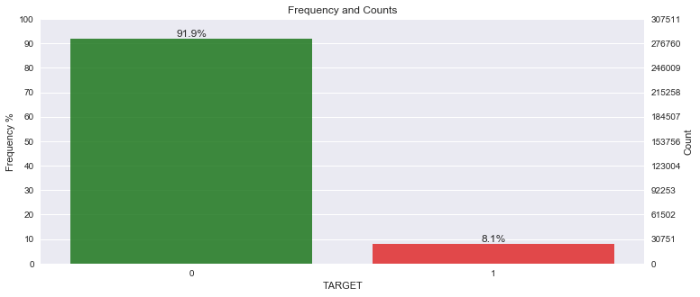

```python
# Target variable (1 - client with payment difficulties:
# he/she had late payment more than X days on at least one of the first Y installments of the loan in our sample,
# 0 - all other cases)

vs.plot_counts(application_train, 'TARGET')
```

**The majority of clients did not have payment difficulties so the TARGET variable is an imbalanced class.**

### application_{train|test}.csv

- This is the main table, broken into two files for Train (with TARGET) and Test (without TARGET).
- Static data for all applications. One row represents one loan in our data sample.

```python
# Add SOURCE column to identify Train vs. Test
application_train['SOURCE'] = 'TRAIN'
application_test['SOURCE'] = 'TEST'

# Combine train and test datasets so data analysis includes combined train and test datasets
application_combined = pd.concat([application_train, application_test])
```

**Based on a review of the column descriptions metadata application data contains a lot of columns that are related to potential protected classes such as gender, family status, age and a variety of statistics about the applicants living area. Even if these had predictive power these could pose potential discriminatory issues in a model. For example, a particular region does show higher instances of payment issues so loans won't be made to applicants that live in this region. That is [redlining](https://en.wikipedia.org/wiki/Redlining). In addition in an attempt to reduce the feature space of potentially irrelevant columns intuition was used to drop additional columns to make it easier for exploratory analysis.**

```python
# Drop any column that could pose potential discriminatory issues using in a model
# Gender, Family Status, Age, Area of Residence (Redlining), Type of Housing
drop_cols(application_combined, ['CODE_GENDER', 'CNT_CHILDREN', 'NAME_TYPE_SUITE', 'NAME_FAMILY_STATUS',
                                 'DAYS_BIRTH', 'CNT_FAM_MEMBERS', 'REG_REGION_NOT_LIVE_REGION',
                                 'REG_REGION_NOT_WORK_REGION', 'LIVE_REGION_NOT_WORK_REGION',
                                 'REG_CITY_NOT_LIVE_CITY', 'REG_CITY_NOT_WORK_CITY',
                                 'LIVE_CITY_NOT_WORK_CITY', 'REGION_POPULATION_RELATIVE',
                                 'REGION_RATING_CLIENT', 'REGION_RATING_CLIENT_W_CITY','APARTMENTS_AVG',
                                 'BASEMENTAREA_AVG', 'YEARS_BEGINEXPLUATATION_AVG', 'YEARS_BUILD_AVG',
                                 'COMMONAREA_AVG', 'ELEVATORS_AVG', 'ENTRANCES_AVG', 'FLOORSMAX_AVG',
                                 'FLOORSMIN_AVG', 'LANDAREA_AVG', 'LIVINGAPARTMENTS_AVG', 'LIVINGAREA_AVG',
                                 'NONLIVINGAPARTMENTS_AVG','NONLIVINGAREA_AVG', 'APARTMENTS_MODE',
                                 'BASEMENTAREA_MODE', 'YEARS_BEGINEXPLUATATION_MODE','YEARS_BUILD_MODE',
                                 'COMMONAREA_MODE', 'ELEVATORS_MODE', 'ENTRANCES_MODE', 'FLOORSMAX_MODE',
                                 'FLOORSMIN_MODE', 'LANDAREA_MODE', 'LIVINGAPARTMENTS_MODE',
                                 'LIVINGAREA_MODE', 'NONLIVINGAPARTMENTS_MODE', 'NONLIVINGAREA_MODE',
                                 'APARTMENTS_MEDI', 'BASEMENTAREA_MEDI', 'YEARS_BEGINEXPLUATATION_MEDI',
                                 'YEARS_BUILD_MEDI', 'COMMONAREA_MEDI', 'ELEVATORS_MEDI', 'ENTRANCES_MEDI',
                                 'FLOORSMAX_MEDI', 'FLOORSMIN_MEDI', 'LANDAREA_MEDI',
                                 'LIVINGAPARTMENTS_MEDI', 'LIVINGAREA_MEDI', 'NONLIVINGAPARTMENTS_MEDI',
                                 'NONLIVINGAREA_MEDI', 'FONDKAPREMONT_MODE', 'HOUSETYPE_MODE',
                                 'TOTALAREA_MODE', 'WALLSMATERIAL_MODE', 'EMERGENCYSTATE_MODE',
                                 # Columns to drop based on intuition
                                 'WEEKDAY_APPR_PROCESS_START', 'HOUR_APPR_PROCESS_START',
                                 'FLAG_MOBIL', 'FLAG_EMP_PHONE' , 'FLAG_WORK_PHONE' ,'FLAG_CONT_MOBILE',
                                 'FLAG_PHONE', 'FLAG_EMAIL', 'OWN_CAR_AGE',
                                 ])

# Display top n records
display(application_combined.head(n=1))
```

|  | AMT_ANNUITY | AMT_CREDIT | AMT_GOODS_PRICE | AMT_INCOME_TOTAL | AMT_REQ_CREDIT_BUREAU_DAY | AMT_REQ_CREDIT_BUREAU_HOUR | AMT_REQ_CREDIT_BUREAU_MON | AMT_REQ_CREDIT_BUREAU_QRT | AMT_REQ_CREDIT_BUREAU_WEEK | AMT_REQ_CREDIT_BUREAU_YEAR | ... | NAME_EDUCATION_TYPE | NAME_HOUSING_TYPE | NAME_INCOME_TYPE | OBS_30_CNT_SOCIAL_CIRCLE | OBS_60_CNT_SOCIAL_CIRCLE | OCCUPATION_TYPE | ORGANIZATION_TYPE | SK_ID_CURR | SOURCE | TARGET |
| --- | --- | --- | --- | --- | --- | --- | --- | --- | --- | --- | --- | --- | --- | --- | --- | --- | --- | --- | --- | --- | --- |
| 0 | 24700.5 | 406597.5 | 351000.0 | 202500.0 | 0.0 | 0.0 | 0.0 | 0.0 | 0.0 | 1.0 | ... | Secondary / secondary special | House / apartment | Working | 2.0 | 2.0 | Laborers | Business Entity Type 3 | 100002 | TRAIN | 1.0 |

1 rows × 52 columns

```python
# Get columns nan counts
nan_counts = pd.DataFrame(application_combined.isnull().sum())

nan_counts.reset_index(level=0, inplace=True)

# Select counts > 0
nan_counts[nan_counts[0] > 1000]
```

|  | index | 0 |
| --- | --- | --- |
| 4 | AMT_REQ_CREDIT_BUREAU_DAY | 47568 |
| 5 | AMT_REQ_CREDIT_BUREAU_HOUR | 47568 |
| 6 | AMT_REQ_CREDIT_BUREAU_MON | 47568 |
| 7 | AMT_REQ_CREDIT_BUREAU_QRT | 47568 |
| 8 | AMT_REQ_CREDIT_BUREAU_WEEK | 47568 |
| 9 | AMT_REQ_CREDIT_BUREAU_YEAR | 47568 |
| 14 | DEF_30_CNT_SOCIAL_CIRCLE | 1050 |
| 15 | DEF_60_CNT_SOCIAL_CIRCLE | 1050 |
| 16 | EXT_SOURCE_1 | 193910 |
| 18 | EXT_SOURCE_3 | 69633 |
| 45 | OBS_30_CNT_SOCIAL_CIRCLE | 1050 |
| 46 | OBS_60_CNT_SOCIAL_CIRCLE | 1050 |
| 47 | OCCUPATION_TYPE | 111996 |
| 51 | TARGET | 48744 |

```python
application_combined[['EXT_SOURCE_1','EXT_SOURCE_2', 'EXT_SOURCE_3']][application_combined['EXT_SOURCE_1']
                                                                      .isnull()].head(5)
```

|  | EXT_SOURCE_1 | EXT_SOURCE_2 | EXT_SOURCE_3 |
| --- | --- | --- | --- |
| 2 | NaN | 0.555912 | 0.729567 |
| 3 | NaN | 0.650442 | NaN |
| 4 | NaN | 0.322738 | NaN |
| 5 | NaN | 0.354225 | 0.621226 |
| 7 | NaN | 0.714279 | 0.540654 |

```python
# Review Categorical variables to identify features that potentially will need dummy variables created
application_combined.describe(include=['O'])
```

|  | FLAG_OWN_CAR | FLAG_OWN_REALTY | NAME_CONTRACT_TYPE | NAME_EDUCATION_TYPE | NAME_HOUSING_TYPE | NAME_INCOME_TYPE | OCCUPATION_TYPE | ORGANIZATION_TYPE | SOURCE |
| --- | --- | --- | --- | --- | --- | --- | --- | --- | --- |
| count | 356255 | 356255 | 356255 | 356255 | 356255 | 356255 | 244259 | 356255 | 356255 |
| unique | 2 | 2 | 2 | 5 | 6 | 8 | 18 | 58 | 2 |
| top | N | Y | Cash loans | Secondary / secondary special | House / apartment | Working | Laborers | Business Entity Type 3 | TRAIN |
| freq | 235235 | 246970 | 326537 | 252379 | 316513 | 183307 | 63841 | 78832 | 307511 |

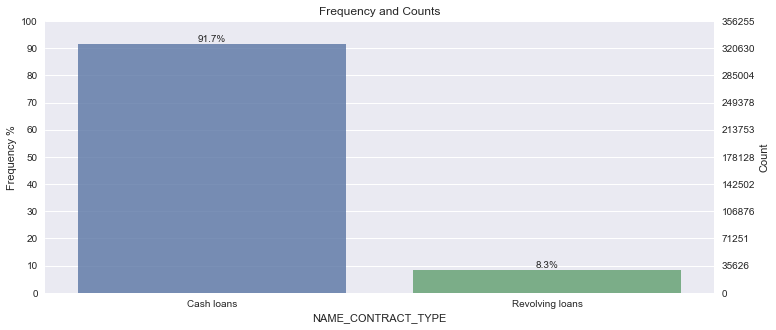

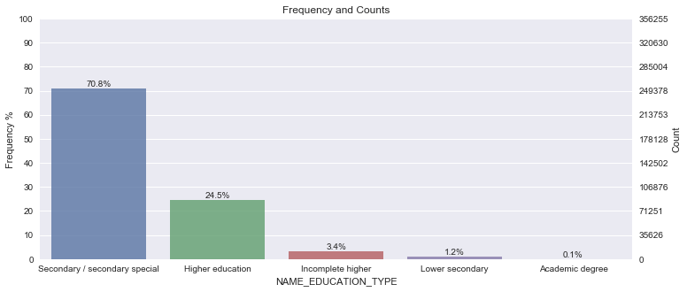

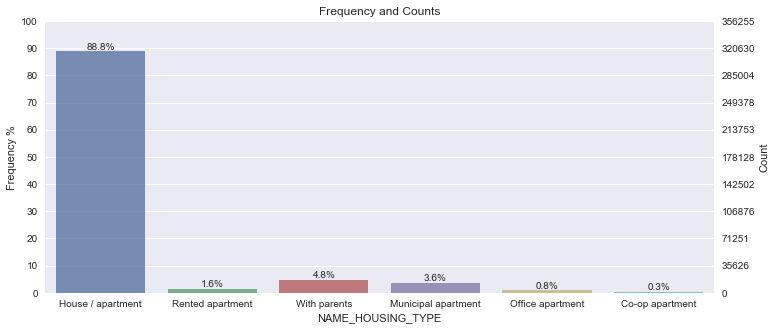

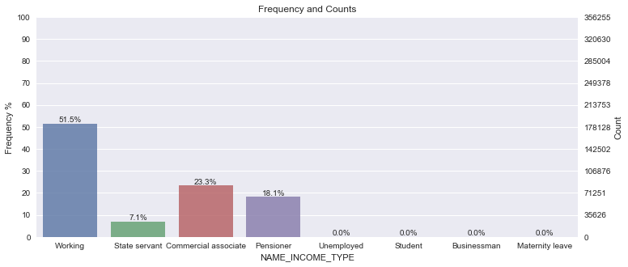

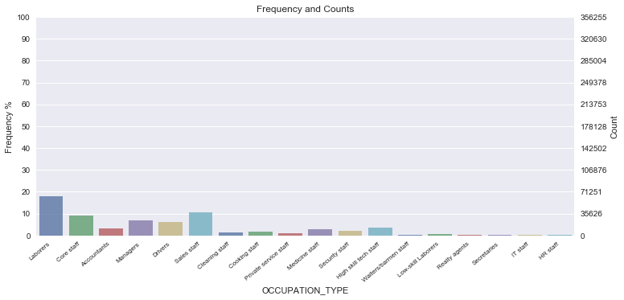

```python
# Plot counts for designated features
categorical_features  = ['NAME_CONTRACT_TYPE', 'NAME_EDUCATION_TYPE', 'NAME_HOUSING_TYPE',
                         'NAME_INCOME_TYPE', 'OCCUPATION_TYPE']

for f in categorical_features:
    vs.plot_counts(application_combined, f)
```

```python
# Convert application categorical to dummy columns
application_combined, application_dummy_cols_output = create_dummy(application_combined, categorical_features)

# Display top n records
display(application_combined.head(n=1))
```

```
Dummy columns created!
```

|  | AMT_ANNUITY | AMT_CREDIT | AMT_GOODS_PRICE | AMT_INCOME_TOTAL | AMT_REQ_CREDIT_BUREAU_DAY | AMT_REQ_CREDIT_BUREAU_HOUR | AMT_REQ_CREDIT_BUREAU_MON | AMT_REQ_CREDIT_BUREAU_QRT | AMT_REQ_CREDIT_BUREAU_WEEK | AMT_REQ_CREDIT_BUREAU_YEAR | ... | OCCUPATION_TYPE_Laborers | OCCUPATION_TYPE_Low-skill Laborers | OCCUPATION_TYPE_Managers | OCCUPATION_TYPE_Medicine staff | OCCUPATION_TYPE_Private service staff | OCCUPATION_TYPE_Realty agents | OCCUPATION_TYPE_Sales staff | OCCUPATION_TYPE_Secretaries | OCCUPATION_TYPE_Security staff | OCCUPATION_TYPE_Waiters/barmen staff |
| --- | --- | --- | --- | --- | --- | --- | --- | --- | --- | --- | --- | --- | --- | --- | --- | --- | --- | --- | --- | --- | --- |
| 0 | 24700.5 | 406597.5 | 351000.0 | 202500.0 | 0.0 | 0.0 | 0.0 | 0.0 | 0.0 | 1.0 | ... | 1 | 0 | 0 | 0 | 0 | 0 | 0 | 0 | 0 | 0 |

1 rows × 91 columns

```python
# Drop categorical features + ORGANIZATION_TYPE
# ORGANIZATION_TYPE has 58 different values so will just this feature
categorical_features_drop = categorical_features + ['ORGANIZATION_TYPE']

# Drop columns
drop_cols(application_combined, categorical_features_drop)

# Display top n records
display(application_combined.head(n=1))
```

|  | AMT_ANNUITY | AMT_CREDIT | AMT_GOODS_PRICE | AMT_INCOME_TOTAL | AMT_REQ_CREDIT_BUREAU_DAY | AMT_REQ_CREDIT_BUREAU_HOUR | AMT_REQ_CREDIT_BUREAU_MON | AMT_REQ_CREDIT_BUREAU_QRT | AMT_REQ_CREDIT_BUREAU_WEEK | AMT_REQ_CREDIT_BUREAU_YEAR | ... | OCCUPATION_TYPE_Laborers | OCCUPATION_TYPE_Low-skill Laborers | OCCUPATION_TYPE_Managers | OCCUPATION_TYPE_Medicine staff | OCCUPATION_TYPE_Private service staff | OCCUPATION_TYPE_Realty agents | OCCUPATION_TYPE_Sales staff | OCCUPATION_TYPE_Secretaries | OCCUPATION_TYPE_Security staff | OCCUPATION_TYPE_Waiters/barmen staff |
| --- | --- | --- | --- | --- | --- | --- | --- | --- | --- | --- | --- | --- | --- | --- | --- | --- | --- | --- | --- | --- | --- |
| 0 | 24700.5 | 406597.5 | 351000.0 | 202500.0 | 0.0 | 0.0 | 0.0 | 0.0 | 0.0 | 1.0 | ... | 1 | 0 | 0 | 0 | 0 | 0 | 0 | 0 | 0 | 0 |

1 rows × 85 columns

```python
# Identify FLAG fields and convert them to binary fields
flag_fields = [c for c in list(application_combined) if 'FLAG' in c]

# Create column naming dict
flag_dict = dict((k, k.replace('FLAG_', '')) for k in flag_fields)

# Convert flag fields
convert_flag(application_combined, flag_dict)

# Display top n records
display(application_combined.head(n=1))
```

|  | AMT_ANNUITY | AMT_CREDIT | AMT_GOODS_PRICE | AMT_INCOME_TOTAL | AMT_REQ_CREDIT_BUREAU_DAY | AMT_REQ_CREDIT_BUREAU_HOUR | AMT_REQ_CREDIT_BUREAU_MON | AMT_REQ_CREDIT_BUREAU_QRT | AMT_REQ_CREDIT_BUREAU_WEEK | AMT_REQ_CREDIT_BUREAU_YEAR | ... | DOCUMENT_12 | DOCUMENT_13 | DOCUMENT_10 | DOCUMENT_11 | DOCUMENT_16 | DOCUMENT_17 | DOCUMENT_14 | DOCUMENT_15 | DOCUMENT_18 | DOCUMENT_19 |
| --- | --- | --- | --- | --- | --- | --- | --- | --- | --- | --- | --- | --- | --- | --- | --- | --- | --- | --- | --- | --- | --- |
| 0 | 24700.5 | 406597.5 | 351000.0 | 202500.0 | 0.0 | 0.0 | 0.0 | 0.0 | 0.0 | 1.0 | ... | 0 | 0 | 0 | 0 | 0 | 0 | 0 | 0 | 0 | 0 |

1 rows × 107 columns

```python
# Drop columns
drop_cols(application_combined, flag_fields)

# Display top n records
display(application_combined.head(n=1))
```

|  | AMT_ANNUITY | AMT_CREDIT | AMT_GOODS_PRICE | AMT_INCOME_TOTAL | AMT_REQ_CREDIT_BUREAU_DAY | AMT_REQ_CREDIT_BUREAU_HOUR | AMT_REQ_CREDIT_BUREAU_MON | AMT_REQ_CREDIT_BUREAU_QRT | AMT_REQ_CREDIT_BUREAU_WEEK | AMT_REQ_CREDIT_BUREAU_YEAR | ... | DOCUMENT_12 | DOCUMENT_13 | DOCUMENT_10 | DOCUMENT_11 | DOCUMENT_16 | DOCUMENT_17 | DOCUMENT_14 | DOCUMENT_15 | DOCUMENT_18 | DOCUMENT_19 |
| --- | --- | --- | --- | --- | --- | --- | --- | --- | --- | --- | --- | --- | --- | --- | --- | --- | --- | --- | --- | --- | --- |
| 0 | 24700.5 | 406597.5 | 351000.0 | 202500.0 | 0.0 | 0.0 | 0.0 | 0.0 | 0.0 | 1.0 | ... | 0 | 0 | 0 | 0 | 0 | 0 | 0 | 0 | 0 | 0 |

1 rows × 85 columns

```python
application_combined.info()
```

```
<class 'pandas.core.frame.DataFrame'>
Int64Index: 356255 entries, 0 to 48743
Data columns (total 85 columns):
AMT_ANNUITY                                          356219 non-null float64
AMT_CREDIT                                           356255 non-null float64
AMT_GOODS_PRICE                                      355977 non-null float64
AMT_INCOME_TOTAL                                     356255 non-null float64
AMT_REQ_CREDIT_BUREAU_DAY                            308687 non-null float64
AMT_REQ_CREDIT_BUREAU_HOUR                           308687 non-null float64
AMT_REQ_CREDIT_BUREAU_MON                            308687 non-null float64
AMT_REQ_CREDIT_BUREAU_QRT                            308687 non-null float64
AMT_REQ_CREDIT_BUREAU_WEEK                           308687 non-null float64
AMT_REQ_CREDIT_BUREAU_YEAR                           308687 non-null float64
DAYS_EMPLOYED                                        356255 non-null int64
DAYS_ID_PUBLISH                                      356255 non-null int64
DAYS_LAST_PHONE_CHANGE                               356254 non-null float64
DAYS_REGISTRATION                                    356255 non-null float64
DEF_30_CNT_SOCIAL_CIRCLE                             355205 non-null float64
DEF_60_CNT_SOCIAL_CIRCLE                             355205 non-null float64
EXT_SOURCE_1                                         162345 non-null float64
EXT_SOURCE_2                                         355587 non-null float64
EXT_SOURCE_3                                         286622 non-null float64
OBS_30_CNT_SOCIAL_CIRCLE                             355205 non-null float64
OBS_60_CNT_SOCIAL_CIRCLE                             355205 non-null float64
SK_ID_CURR                                           356255 non-null int64
SOURCE                                               356255 non-null object
TARGET                                               307511 non-null float64
NAME_CONTRACT_TYPE_Cash loans                        356255 non-null uint8
NAME_CONTRACT_TYPE_Revolving loans                   356255 non-null uint8
NAME_EDUCATION_TYPE_Academic degree                  356255 non-null uint8
NAME_EDUCATION_TYPE_Higher education                 356255 non-null uint8
NAME_EDUCATION_TYPE_Incomplete higher                356255 non-null uint8
NAME_EDUCATION_TYPE_Lower secondary                  356255 non-null uint8
NAME_EDUCATION_TYPE_Secondary / secondary special    356255 non-null uint8
NAME_HOUSING_TYPE_Co-op apartment                    356255 non-null uint8
NAME_HOUSING_TYPE_House / apartment                  356255 non-null uint8
NAME_HOUSING_TYPE_Municipal apartment                356255 non-null uint8
NAME_HOUSING_TYPE_Office apartment                   356255 non-null uint8
NAME_HOUSING_TYPE_Rented apartment                   356255 non-null uint8
NAME_HOUSING_TYPE_With parents                       356255 non-null uint8
```

[output cut: 35 more lines]

```
DOCUMENT_6                                           356255 non-null int64
DOCUMENT_7                                           356255 non-null int64
OWN_REALTY                                           356255 non-null int64
DOCUMENT_12                                          356255 non-null int64
DOCUMENT_13                                          356255 non-null int64
DOCUMENT_10                                          356255 non-null int64
DOCUMENT_11                                          356255 non-null int64
DOCUMENT_16                                          356255 non-null int64
DOCUMENT_17                                          356255 non-null int64
DOCUMENT_14                                          356255 non-null int64
DOCUMENT_15                                          356255 non-null int64
DOCUMENT_18                                          356255 non-null int64
DOCUMENT_19                                          356255 non-null int64
dtypes: float64(20), int64(25), object(1), uint8(39)
memory usage: 151.0+ MB
```

#### bureau.csv

- All client's previous credits provided by other financial institutions that were reported to Credit Bureau (for clients who have a loan in our sample).
- For every loan in our sample, there are as many rows as number of credits the client had in Credit Bureau before the application date.

#### bureau_balance.csv

- Monthly balances of previous credits in Credit Bureau.
- This table has one row for each month of history of every previous credit reported to Credit Bureau – i.e the table has (#loans in sample *# of relative previous credits* # of months where we have some history observable for the previous credits) rows.

```python
# Review Categorical variables to identify features that potentially will need dummy variables created
bureau.describe(include=['O'])
```

|  | CREDIT_ACTIVE | CREDIT_CURRENCY | CREDIT_TYPE |
| --- | --- | --- | --- |
| count | 1716428 | 1716428 | 1716428 |
| unique | 4 | 4 | 15 |
| top | Closed | currency 1 | Consumer credit |
| freq | 1079273 | 1715020 | 1251615 |

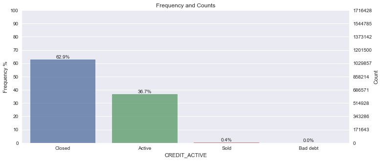

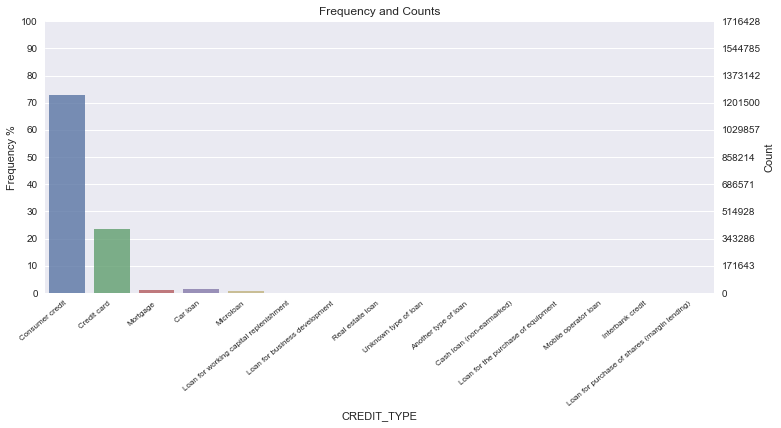

```python
# Plot counts for designated features
bureau_categorical_features = ['CREDIT_ACTIVE', 'CREDIT_TYPE']

for f in bureau_categorical_features:
    vs.plot_counts(bureau, f)
```

```python
# Create dummy columns
bureau, bureau_dummy_cols_output = create_dummy(bureau, bureau_categorical_features)

# Display top n records
display(bureau.head(n=1))
```

```
Dummy columns created!
```

|  | SK_ID_CURR | SK_ID_BUREAU | CREDIT_ACTIVE | CREDIT_CURRENCY | DAYS_CREDIT | CREDIT_DAY_OVERDUE | DAYS_CREDIT_ENDDATE | DAYS_ENDDATE_FACT | AMT_CREDIT_MAX_OVERDUE | CNT_CREDIT_PROLONG | ... | CREDIT_TYPE_Interbank credit | CREDIT_TYPE_Loan for business development | CREDIT_TYPE_Loan for purchase of shares (margin lending) | CREDIT_TYPE_Loan for the purchase of equipment | CREDIT_TYPE_Loan for working capital replenishment | CREDIT_TYPE_Microloan | CREDIT_TYPE_Mobile operator loan | CREDIT_TYPE_Mortgage | CREDIT_TYPE_Real estate loan | CREDIT_TYPE_Unknown type of loan |
| --- | --- | --- | --- | --- | --- | --- | --- | --- | --- | --- | --- | --- | --- | --- | --- | --- | --- | --- | --- | --- | --- |
| 0 | 215354 | 5714462 | Closed | currency 1 | -497 | 0 | -153.0 | -153.0 | NaN | 0 | ... | 0 | 0 | 0 | 0 | 0 | 0 | 0 | 0 | 0 | 0 |

1 rows × 36 columns

```python
# Column to sum for all bureau records
bureau['BUREAU_COUNT'] = 1

# Bureau records within 30 days of application
bureau.loc[(bureau['DAYS_CREDIT'] <= 0) & (bureau['DAYS_CREDIT'] >= -30), 'BUREAU_COUNT_30'] = 1
# Bureau records within 31-60 days of application
bureau.loc[(bureau['DAYS_CREDIT'] <= -31) & (bureau['DAYS_CREDIT'] >= -60), 'BUREAU_COUNT_60'] = 1
# Bureau records within 61-120 days of application
bureau.loc[(bureau['DAYS_CREDIT'] <= -61) & (bureau['DAYS_CREDIT'] >= -120), 'BUREAU_COUNT_120'] = 1
# Bureau records >= 121 days of application
bureau.loc[(bureau['DAYS_CREDIT'] <= -121), 'BUREAU_COUNT_121_GT'] = 1

# Columns to sum + key
# Do not rename dummy columns so they can be added to list raw for aggregate
bureau_sum_cols = ['SK_ID_CURR', 'BUREAU_COUNT' , 'BUREAU_COUNT_30', 'BUREAU_COUNT_60',
                   'BUREAU_COUNT_120', 'BUREAU_COUNT_121_GT'] + bureau_dummy_cols_output

# Get sums
bureau_grouped = perform_aggregate(bureau[bureau_sum_cols], ['SK_ID_CURR'], 'sum')

# Display top n records
display(bureau_grouped.head(n=1))
```

|  | SK_ID_CURR | BUREAU_COUNT_SUM | BUREAU_COUNT_30_SUM | BUREAU_COUNT_60_SUM | BUREAU_COUNT_120_SUM | BUREAU_COUNT_121_GT_SUM | CREDIT_ACTIVE_ACTIVE_SUM | CREDIT_ACTIVE_BAD_DEBT_SUM | CREDIT_ACTIVE_CLOSED_SUM | CREDIT_ACTIVE_SOLD_SUM | ... | CREDIT_TYPE_INTERBANK_CREDIT_SUM | CREDIT_TYPE_LOAN_FOR_BUSINESS_DEVELOPMENT_SUM | CREDIT_TYPE_LOAN_FOR_PURCHASE_OF_SHARES_(MARGIN_LENDING)_SUM | CREDIT_TYPE_LOAN_FOR_THE_PURCHASE_OF_EQUIPMENT_SUM | CREDIT_TYPE_LOAN_FOR_WORKING_CAPITAL_REPLENISHMENT_SUM | CREDIT_TYPE_MICROLOAN_SUM | CREDIT_TYPE_MOBILE_OPERATOR_LOAN_SUM | CREDIT_TYPE_MORTGAGE_SUM | CREDIT_TYPE_REAL_ESTATE_LOAN_SUM | CREDIT_TYPE_UNKNOWN_TYPE_OF_LOAN_SUM |
| --- | --- | --- | --- | --- | --- | --- | --- | --- | --- | --- | --- | --- | --- | --- | --- | --- | --- | --- | --- | --- | --- |
| 0 | 100001 | 7 | 0.0 | 1.0 | 0.0 | 6.0 | 3 | 0 | 4 | 0 | ... | 0 | 0 | 0 | 0 | 0 | 0 | 0 | 0 | 0 | 0 |

1 rows × 25 columns

```python
# Bureau data can include inactive accounts so isolating only active will be important
# Get Active bureau accounts
bureau_active = bureau[bureau['CREDIT_ACTIVE'] == 'Active'].copy()

# Clean columns
bureau_active = rename_cols_df(bureau_active, list(bureau_active), None)

print("Active bureau records: {}".format(len(bureau_active)))

# Display top n records
display(bureau_active.head(n=1))
```

```
Active bureau records: 630607
```

|  | SK_ID_CURR | SK_ID_BUREAU | CREDIT_ACTIVE | CREDIT_CURRENCY | DAYS_CREDIT | CREDIT_DAY_OVERDUE | DAYS_CREDIT_ENDDATE | DAYS_ENDDATE_FACT | AMT_CREDIT_MAX_OVERDUE | CNT_CREDIT_PROLONG | ... | CREDIT_TYPE_MICROLOAN | CREDIT_TYPE_MOBILE_OPERATOR_LOAN | CREDIT_TYPE_MORTGAGE | CREDIT_TYPE_REAL_ESTATE_LOAN | CREDIT_TYPE_UNKNOWN_TYPE_OF_LOAN | BUREAU_COUNT | BUREAU_COUNT_30 | BUREAU_COUNT_60 | BUREAU_COUNT_120 | BUREAU_COUNT_121_GT |
| --- | --- | --- | --- | --- | --- | --- | --- | --- | --- | --- | --- | --- | --- | --- | --- | --- | --- | --- | --- | --- | --- |
| 1 | 215354 | 5714463 | Active | currency 1 | -208 | 0 | 1075.0 | NaN | NaN | 0 | ... | 0 | 0 | 0 | 0 | 0 | 1 | NaN | NaN | NaN | 1.0 |

1 rows × 41 columns

```python
# Columns to sum + key
# Based on a review of the count plot only include designated credit types
bureau_active_sum_cols = ['SK_ID_CURR', 'AMT_CREDIT_MAX_OVERDUE', 'AMT_CREDIT_SUM', 'AMT_CREDIT_SUM_DEBT',
                          'AMT_CREDIT_SUM_LIMIT', 'AMT_CREDIT_SUM_OVERDUE', 'AMT_ANNUITY',
                         'CREDIT_TYPE_CONSUMER_CREDIT', 'CREDIT_TYPE_CREDIT_CARD', 'CREDIT_TYPE_MORTGAGE',
                         'CREDIT_TYPE_CAR_LOAN', 'CREDIT_TYPE_MICROLOAN']

# Get sums
bureau_active_grouped = perform_aggregate(bureau_active[bureau_active_sum_cols], ['SK_ID_CURR'], 'sum')

# Add _ACTIVE suffix for final features
bureau_active_grouped = rename_cols_df(bureau_active_grouped, list(bureau_active_grouped), 'active')

# Display top n records
display(bureau_active_grouped.head(n=1))
```

|  | SK_ID_CURR | AMT_CREDIT_MAX_OVERDUE_SUM_ACTIVE | AMT_CREDIT_SUM_SUM_ACTIVE | AMT_CREDIT_SUM_DEBT_SUM_ACTIVE | AMT_CREDIT_SUM_LIMIT_SUM_ACTIVE | AMT_CREDIT_SUM_OVERDUE_SUM_ACTIVE | AMT_ANNUITY_SUM_ACTIVE | CREDIT_TYPE_CONSUMER_CREDIT_SUM_ACTIVE | CREDIT_TYPE_CREDIT_CARD_SUM_ACTIVE | CREDIT_TYPE_MORTGAGE_SUM_ACTIVE | CREDIT_TYPE_CAR_LOAN_SUM_ACTIVE | CREDIT_TYPE_MICROLOAN_SUM_ACTIVE |
| --- | --- | --- | --- | --- | --- | --- | --- | --- | --- | --- | --- | --- |
| 0 | 100001 | 0.0 | 884025.0 | 596686.5 | 0.0 | 0.0 | 24817.5 | 3 | 0 | 0 | 0 | 0 |

```python
# Merge dict for bureau_grouped
bureau_grouped_merge_dict = {0: {'left': bureau_grouped,
                                 'right': bureau_active_grouped,
                                 'how': 'left',
                                 'on': ['SK_ID_CURR']
                                }}

# Merge dfs
bureau_grouped_final = merge_df(bureau_grouped_merge_dict)

# Display top n records
display(bureau_grouped_final.head(n=1))
```

|  | SK_ID_CURR | BUREAU_COUNT_SUM | BUREAU_COUNT_30_SUM | BUREAU_COUNT_60_SUM | BUREAU_COUNT_120_SUM | BUREAU_COUNT_121_GT_SUM | CREDIT_ACTIVE_ACTIVE_SUM | CREDIT_ACTIVE_BAD_DEBT_SUM | CREDIT_ACTIVE_CLOSED_SUM | CREDIT_ACTIVE_SOLD_SUM | ... | AMT_CREDIT_SUM_SUM_ACTIVE | AMT_CREDIT_SUM_DEBT_SUM_ACTIVE | AMT_CREDIT_SUM_LIMIT_SUM_ACTIVE | AMT_CREDIT_SUM_OVERDUE_SUM_ACTIVE | AMT_ANNUITY_SUM_ACTIVE | CREDIT_TYPE_CONSUMER_CREDIT_SUM_ACTIVE | CREDIT_TYPE_CREDIT_CARD_SUM_ACTIVE | CREDIT_TYPE_MORTGAGE_SUM_ACTIVE | CREDIT_TYPE_CAR_LOAN_SUM_ACTIVE | CREDIT_TYPE_MICROLOAN_SUM_ACTIVE |
| --- | --- | --- | --- | --- | --- | --- | --- | --- | --- | --- | --- | --- | --- | --- | --- | --- | --- | --- | --- | --- | --- |
| 0 | 100001 | 7 | 0.0 | 1.0 | 0.0 | 6.0 | 3 | 0 | 4 | 0 | ... | 884025.0 | 596686.5 | 0.0 | 0.0 | 24817.5 | 3.0 | 0.0 | 0.0 | 0.0 | 0.0 |

1 rows × 36 columns

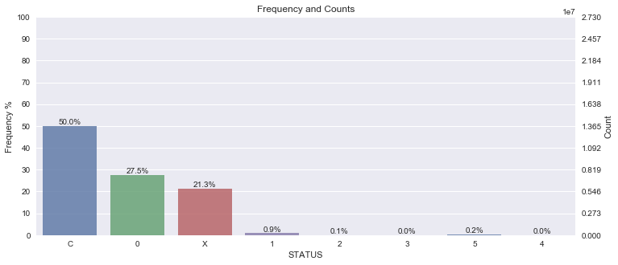

```python
# Based on review of dictionary there is only 1 categorical feature in bureau_balance
vs.plot_counts(bureau_balance, 'STATUS')
```

```python
# Status of Credit Bureau loan during the month (active, closed, DPD0-30,
# [C means closed,
# X means status unknown,
# 0 means no DPD,
# 1 means maximal did during month between 1-30,
# 2 means DPD 31-60,
# 5 means DPD 120+ or sold or written off ] )

# Create dummy columns
bureau_balance, bureau_balance_dummy_cols_output = create_dummy(bureau_balance, ['STATUS'])

# Merge dict for bureau_balance
bureau_balance_merge_dict = {0: {'left': bureau[['SK_ID_CURR', 'SK_ID_BUREAU']],
                                 'right': bureau_balance,
                                 'how': 'inner',
                                 'on': ['SK_ID_BUREAU']
                                }}

# Add SK_ID_CURR to bureau_balance based on SK_ID_BUREAU
bureau_balance = merge_df(bureau_balance_merge_dict)

# Display top n records
display(bureau_balance.head(n=1))
```

```
Dummy columns created!
```

|  | SK_ID_CURR | SK_ID_BUREAU | MONTHS_BALANCE | STATUS | STATUS_0 | STATUS_1 | STATUS_2 | STATUS_3 | STATUS_4 | STATUS_5 | STATUS_C | STATUS_X |
| --- | --- | --- | --- | --- | --- | --- | --- | --- | --- | --- | --- | --- |
| 0 | 380361 | 5715448 | 0 | C | 0 | 0 | 0 | 0 | 0 | 0 | 1 | 0 |

```python
# Columns to sum + key
bureau_balance_sum_cols = ['SK_ID_CURR'] + bureau_balance_dummy_cols_output

# Get sums
bureau_balance_grouped = perform_aggregate(bureau_balance[bureau_balance_sum_cols], ['SK_ID_CURR'], 'sum')

# Add _HIST suffix for final features
bureau_balance_grouped = rename_cols_df(bureau_balance_grouped, list(bureau_balance_grouped), 'hist')

# Display top n records
display(bureau_balance_grouped.head(n=1))
```

|  | SK_ID_CURR | STATUS_0_SUM_HIST | STATUS_1_SUM_HIST | STATUS_2_SUM_HIST | STATUS_3_SUM_HIST | STATUS_4_SUM_HIST | STATUS_5_SUM_HIST | STATUS_C_SUM_HIST | STATUS_X_SUM_HIST |
| --- | --- | --- | --- | --- | --- | --- | --- | --- | --- |
| 0 | 100001 | 31.0 | 1.0 | 0.0 | 0.0 | 0.0 | 0.0 | 110.0 | 30.0 |

```python
# Get latest MONTHS_BALANCE for SK_ID_BUREAU
bureau_balance_max_cols = ['SK_ID_BUREAU', 'MONTHS_BALANCE']

# Get latest MONTHS_BALANCE for SK_ID_BUREAU
bureau_balance_max = perform_aggregate(bureau_balance[bureau_balance_max_cols], ['SK_ID_BUREAU'], 'max')

# This is one exception for KEYS so remove _MAX for join added on aggregate
# Could use left_on or right_on but this is the only time the merge join has issues
bureau_balance_max.rename(columns={'MONTHS_BALANCE_MAX': 'MONTHS_BALANCE'}, inplace=True)

# Merge dict for bureau_balance_max
bureau_balance_max_merge_dict = {0: {'left': bureau_balance,
                                     'right': bureau_balance_max,
                                     'how': 'inner',
                                     'on': ['SK_ID_BUREAU', 'MONTHS_BALANCE']
                                    }}

# Create new df for latest record with STATUS
bureau_balance_latest = merge_df(bureau_balance_max_merge_dict)

display(bureau_balance_latest.head(n=1))
```

|  | SK_ID_CURR | SK_ID_BUREAU | MONTHS_BALANCE | STATUS | STATUS_0 | STATUS_1 | STATUS_2 | STATUS_3 | STATUS_4 | STATUS_5 | STATUS_C | STATUS_X |
| --- | --- | --- | --- | --- | --- | --- | --- | --- | --- | --- | --- | --- |
| 0 | 380361 | 5715448 | 0 | C | 0 | 0 | 0 | 0 | 0 | 0 | 1 | 0 |

```python
# Get sums
bureau_balance_latest_grouped = perform_aggregate(bureau_balance_latest[bureau_balance_sum_cols], ['SK_ID_CURR'],
                                                  'sum')

# Add _LATEST suffix for final features
bureau_balance_latest_grouped = rename_cols_df(bureau_balance_latest_grouped, list(bureau_balance_latest_grouped),
                                               'latest')

# Display top n records
display(bureau_balance_latest_grouped.head(n=1))
```

|  | SK_ID_CURR | STATUS_0_SUM_LATEST | STATUS_1_SUM_LATEST | STATUS_2_SUM_LATEST | STATUS_3_SUM_LATEST | STATUS_4_SUM_LATEST | STATUS_5_SUM_LATEST | STATUS_C_SUM_LATEST | STATUS_X_SUM_LATEST |
| --- | --- | --- | --- | --- | --- | --- | --- | --- | --- |
| 0 | 100001 | 2 | 1 | 0 | 0 | 0 | 0 | 4 | 0 |

```python
# Merge dict for bureau_balance_grouped_final
bureau_balance_grouped_final_merge_dict = {0: {'left': bureau_balance_grouped,
                                               'right': bureau_balance_latest_grouped,
                                               'how': 'inner',
                                               'on': ['SK_ID_CURR']
                                              }}

# Create final bureau balance grouped with historical and latest sums
bureau_balance_grouped_final = merge_df(bureau_balance_grouped_final_merge_dict)

# Display top n records
display(bureau_balance_grouped_final.head(n=1))
```

|  | SK_ID_CURR | STATUS_0_SUM_HIST | STATUS_1_SUM_HIST | STATUS_2_SUM_HIST | STATUS_3_SUM_HIST | STATUS_4_SUM_HIST | STATUS_5_SUM_HIST | STATUS_C_SUM_HIST | STATUS_X_SUM_HIST | STATUS_0_SUM_LATEST | STATUS_1_SUM_LATEST | STATUS_2_SUM_LATEST | STATUS_3_SUM_LATEST | STATUS_4_SUM_LATEST | STATUS_5_SUM_LATEST | STATUS_C_SUM_LATEST | STATUS_X_SUM_LATEST |
| --- | --- | --- | --- | --- | --- | --- | --- | --- | --- | --- | --- | --- | --- | --- | --- | --- | --- |
| 0 | 100001 | 31.0 | 1.0 | 0.0 | 0.0 | 0.0 | 0.0 | 110.0 | 30.0 | 2 | 1 | 0 | 0 | 0 | 0 | 4 | 0 |

```python
print("Bureau Grouped records: {}".format(len(bureau_grouped_final)))
print("Bureau Balance Grouped records: {}".format(len(bureau_balance_grouped_final)))
```

```
Bureau Grouped records: 305811
Bureau Balance Grouped records: 134542
```

```python
# Merge dict for bureau_combined_grouped_final
bureau_combined_grouped_final_merge_dict = {0: {'left': bureau_grouped_final,
                                               'right': bureau_balance_grouped_final,
                                               'how': 'left',
                                               'on': ['SK_ID_CURR']
                                              }}

# Create final combined bureau grouped and bureau balance grouped
bureau_combined_grouped_final = merge_df(bureau_combined_grouped_final_merge_dict)

# Display top 1 records
display(bureau_combined_grouped_final.head(n=1))
```

|  | SK_ID_CURR | BUREAU_COUNT_SUM | BUREAU_COUNT_30_SUM | BUREAU_COUNT_60_SUM | BUREAU_COUNT_120_SUM | BUREAU_COUNT_121_GT_SUM | CREDIT_ACTIVE_ACTIVE_SUM | CREDIT_ACTIVE_BAD_DEBT_SUM | CREDIT_ACTIVE_CLOSED_SUM | CREDIT_ACTIVE_SOLD_SUM | ... | STATUS_C_SUM_HIST | STATUS_X_SUM_HIST | STATUS_0_SUM_LATEST | STATUS_1_SUM_LATEST | STATUS_2_SUM_LATEST | STATUS_3_SUM_LATEST | STATUS_4_SUM_LATEST | STATUS_5_SUM_LATEST | STATUS_C_SUM_LATEST | STATUS_X_SUM_LATEST |
| --- | --- | --- | --- | --- | --- | --- | --- | --- | --- | --- | --- | --- | --- | --- | --- | --- | --- | --- | --- | --- | --- |
| 0 | 100001 | 7 | 0.0 | 1.0 | 0.0 | 6.0 | 3 | 0 | 4 | 0 | ... | 110.0 | 30.0 | 2.0 | 1.0 | 0.0 | 0.0 | 0.0 | 0.0 | 4.0 | 0.0 |

1 rows × 52 columns

#### previous_application.csv

- All previous applications for Home Credit loans of clients who have loans in our sample.
- There is one row for each previous application related to loans in our data sample.

#### POS_CASH_balance.csv

- Monthly balance snapshots of previous POS (point of sales) and cash loans that the applicant had with Home Credit.
- This table has one row for each month of history of every previous credit in Home Credit (consumer credit and cash loans) related to loans in our sample – i.e. the table has (#loans in sample *# of relative previous credits* # of months in which we have some history observable for the previous credits) rows.

#### credit_card_balance.csv

- Monthly balance snapshots of previous credit cards that the applicant has with Home Credit.
- This table has one row for each month of history of every previous credit in Home Credit (consumer credit and cash loans) related to loans in our sample – i.e. the table has (#loans in sample *# of relative previous credit cards* # of months where we have some history observable for the previous credit card) rows.

#### installments_payments.csv

- Repayment history for the previously disbursed credits in Home Credit related to the loans in our sample.
- There is a) one row for every payment that was made plus b) one row each for missed payment.
- One row is equivalent to one payment of one installment OR one installment corresponding to one payment of one previous Home Credit credit related to loans in our sample.

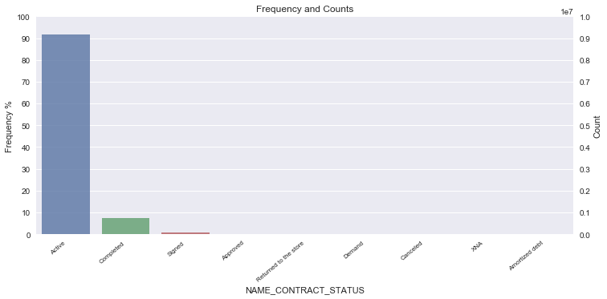

```python
# Based on review of dictionary there is only 1 categorical feature in POS_CASH_balance
vs.plot_counts(POS_CASH_balance, 'NAME_CONTRACT_STATUS')
```

```python
# Create dummy columns
POS_CASH_balance, POS_CASH_balance_dummy_cols_output = create_dummy(POS_CASH_balance, ['NAME_CONTRACT_STATUS'])

# Display top n records
display(POS_CASH_balance.head(n=1))
```

```
Dummy columns created!
```

|  | SK_ID_PREV | SK_ID_CURR | MONTHS_BALANCE | CNT_INSTALMENT | CNT_INSTALMENT_FUTURE | NAME_CONTRACT_STATUS | SK_DPD | SK_DPD_DEF | NAME_CONTRACT_STATUS_Active | NAME_CONTRACT_STATUS_Amortized debt | NAME_CONTRACT_STATUS_Approved | NAME_CONTRACT_STATUS_Canceled | NAME_CONTRACT_STATUS_Completed | NAME_CONTRACT_STATUS_Demand | NAME_CONTRACT_STATUS_Returned to the store | NAME_CONTRACT_STATUS_Signed | NAME_CONTRACT_STATUS_XNA |
| --- | --- | --- | --- | --- | --- | --- | --- | --- | --- | --- | --- | --- | --- | --- | --- | --- | --- |
| 0 | 1803195 | 182943 | -31 | 48.0 | 45.0 | Active | 0 | 0 | 1 | 0 | 0 | 0 | 0 | 0 | 0 | 0 | 0 |

```python
# Columns to sum + key
POS_CASH_balance_sum_cols = ['SK_ID_CURR', 'CNT_INSTALMENT_FUTURE', 'SK_DPD',
                             'SK_DPD_DEF'] + POS_CASH_balance_dummy_cols_output

# Get sums
POS_CASH_balance_grouped = perform_aggregate(POS_CASH_balance[POS_CASH_balance_sum_cols], ['SK_ID_CURR'], 'sum')

# Add _POS_CASH suffix for final features since some columns overlap with other tables
POS_CASH_balance_grouped = rename_cols_df(POS_CASH_balance_grouped, list(POS_CASH_balance_grouped), 'pos_cash')

# Display top n records
display(POS_CASH_balance_grouped.head(n=1))
```

|  | SK_ID_CURR | CNT_INSTALMENT_FUTURE_SUM_POS_CASH | SK_DPD_SUM_POS_CASH | SK_DPD_DEF_SUM_POS_CASH | NAME_CONTRACT_STATUS_ACTIVE_SUM_POS_CASH | NAME_CONTRACT_STATUS_AMORTIZED_DEBT_SUM_POS_CASH | NAME_CONTRACT_STATUS_APPROVED_SUM_POS_CASH | NAME_CONTRACT_STATUS_CANCELED_SUM_POS_CASH | NAME_CONTRACT_STATUS_COMPLETED_SUM_POS_CASH | NAME_CONTRACT_STATUS_DEMAND_SUM_POS_CASH | NAME_CONTRACT_STATUS_RETURNED_TO_THE_STORE_SUM_POS_CASH | NAME_CONTRACT_STATUS_SIGNED_SUM_POS_CASH | NAME_CONTRACT_STATUS_XNA_SUM_POS_CASH |
| --- | --- | --- | --- | --- | --- | --- | --- | --- | --- | --- | --- | --- | --- |
| 0 | 100001 | 13.0 | 7 | 7 | 7.0 | 0.0 | 0.0 | 0.0 | 2.0 | 0.0 | 0.0 | 0.0 | 0.0 |

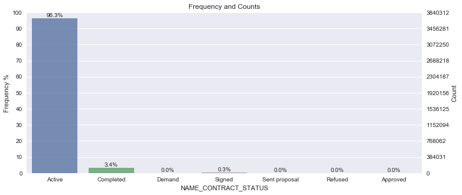

```python
# Based on review of dictionary there is only 1 categorical feature in credit_card_balance
vs.plot_counts(credit_card_balance, 'NAME_CONTRACT_STATUS')
```

```python
# Create dummy columns
credit_card_balance, credit_card_balance_dummy_cols_output = create_dummy(credit_card_balance,
                                                                          ['NAME_CONTRACT_STATUS'])

# Display top n records
display(credit_card_balance.head(n=1))
```

```
Dummy columns created!
```

|  | SK_ID_PREV | SK_ID_CURR | MONTHS_BALANCE | AMT_BALANCE | AMT_CREDIT_LIMIT_ACTUAL | AMT_DRAWINGS_ATM_CURRENT | AMT_DRAWINGS_CURRENT | AMT_DRAWINGS_OTHER_CURRENT | AMT_DRAWINGS_POS_CURRENT | AMT_INST_MIN_REGULARITY | ... | NAME_CONTRACT_STATUS | SK_DPD | SK_DPD_DEF | NAME_CONTRACT_STATUS_Active | NAME_CONTRACT_STATUS_Approved | NAME_CONTRACT_STATUS_Completed | NAME_CONTRACT_STATUS_Demand | NAME_CONTRACT_STATUS_Refused | NAME_CONTRACT_STATUS_Sent proposal | NAME_CONTRACT_STATUS_Signed |
| --- | --- | --- | --- | --- | --- | --- | --- | --- | --- | --- | --- | --- | --- | --- | --- | --- | --- | --- | --- | --- | --- |
| 0 | 2562384 | 378907 | -6 | 56.97 | 135000 | 0.0 | 877.5 | 0.0 | 877.5 | 1700.325 | ... | Active | 0 | 0 | 1 | 0 | 0 | 0 | 0 | 0 | 0 |

1 rows × 30 columns

```python
# Columns to sum + key
credit_card_balance_sum_cols = ['SK_ID_CURR', 'SK_DPD', 'SK_DPD_DEF'] + credit_card_balance_dummy_cols_output

# Get sums
credit_card_balance_grouped = perform_aggregate(credit_card_balance[credit_card_balance_sum_cols], ['SK_ID_CURR'],
                                                  'sum')

# Add _CREDIT_CARD suffix for final features since some columns overlap with other tables
credit_card_balance_grouped = rename_cols_df(credit_card_balance_grouped, list(credit_card_balance_grouped),
                                               'credit_card')

# Display top n records
display(credit_card_balance_grouped.head(n=1))
```

|  | SK_ID_CURR | SK_DPD_SUM_CREDIT_CARD | SK_DPD_DEF_SUM_CREDIT_CARD | NAME_CONTRACT_STATUS_ACTIVE_SUM_CREDIT_CARD | NAME_CONTRACT_STATUS_APPROVED_SUM_CREDIT_CARD | NAME_CONTRACT_STATUS_COMPLETED_SUM_CREDIT_CARD | NAME_CONTRACT_STATUS_DEMAND_SUM_CREDIT_CARD | NAME_CONTRACT_STATUS_REFUSED_SUM_CREDIT_CARD | NAME_CONTRACT_STATUS_SENT_PROPOSAL_SUM_CREDIT_CARD | NAME_CONTRACT_STATUS_SIGNED_SUM_CREDIT_CARD |
| --- | --- | --- | --- | --- | --- | --- | --- | --- | --- | --- |
| 0 | 100006 | 0 | 0 | 6 | 0 | 0 | 0 | 0 | 0 | 0 |

```python
# Get Active credit card balance accounts
credit_card_balance_active = credit_card_balance[credit_card_balance['NAME_CONTRACT_STATUS'] == 'Active'].copy()

print("Active credit card balance records: {}".format(len(credit_card_balance_active)))

# Display top n records
display(credit_card_balance_active.head(n=1))
```

```
Active credit card balance records: 3698436
```

|  | SK_ID_PREV | SK_ID_CURR | MONTHS_BALANCE | AMT_BALANCE | AMT_CREDIT_LIMIT_ACTUAL | AMT_DRAWINGS_ATM_CURRENT | AMT_DRAWINGS_CURRENT | AMT_DRAWINGS_OTHER_CURRENT | AMT_DRAWINGS_POS_CURRENT | AMT_INST_MIN_REGULARITY | ... | NAME_CONTRACT_STATUS | SK_DPD | SK_DPD_DEF | NAME_CONTRACT_STATUS_Active | NAME_CONTRACT_STATUS_Approved | NAME_CONTRACT_STATUS_Completed | NAME_CONTRACT_STATUS_Demand | NAME_CONTRACT_STATUS_Refused | NAME_CONTRACT_STATUS_Sent proposal | NAME_CONTRACT_STATUS_Signed |
| --- | --- | --- | --- | --- | --- | --- | --- | --- | --- | --- | --- | --- | --- | --- | --- | --- | --- | --- | --- | --- | --- |
| 0 | 2562384 | 378907 | -6 | 56.97 | 135000 | 0.0 | 877.5 | 0.0 | 877.5 | 1700.325 | ... | Active | 0 | 0 | 1 | 0 | 0 | 0 | 0 | 0 | 0 |

1 rows × 30 columns

```python
# Columns to sum + key
credit_card_balance_active_sum_cols = ['SK_ID_CURR', 'AMT_BALANCE', 'AMT_CREDIT_LIMIT_ACTUAL' ,
                                       'AMT_DRAWINGS_ATM_CURRENT', 'AMT_DRAWINGS_CURRENT',
                                       'AMT_DRAWINGS_OTHER_CURRENT', 'AMT_DRAWINGS_POS_CURRENT',
                                       'AMT_INST_MIN_REGULARITY', 'AMT_PAYMENT_CURRENT',
                                       'AMT_PAYMENT_TOTAL_CURRENT', 'AMT_RECEIVABLE_PRINCIPAL',
                                       'AMT_RECIVABLE', 'AMT_TOTAL_RECEIVABLE',
                                       'CNT_DRAWINGS_ATM_CURRENT', 'CNT_DRAWINGS_CURRENT',
                                       'CNT_DRAWINGS_OTHER_CURRENT', 'CNT_DRAWINGS_POS_CURRENT',
                                       'CNT_INSTALMENT_MATURE_CUM']

# Get sums
credit_card_balance_active_grouped = perform_aggregate(credit_card_balance_active[credit_card_balance_active_sum_cols],
                                                       ['SK_ID_CURR'], 'sum')

# Add _CREDIT_CARD_ACTIVE suffix for final features since some columns overlap with other tables
credit_card_balance_active_grouped = rename_cols_df(credit_card_balance_active_grouped,
                                                    list(credit_card_balance_active_grouped), 'credit_card_active')

# Display top n records
display(credit_card_balance_active_grouped.head(n=1))
```

|  | SK_ID_CURR | AMT_BALANCE_SUM_CREDIT_CARD_ACTIVE | AMT_CREDIT_LIMIT_ACTUAL_SUM_CREDIT_CARD_ACTIVE | AMT_DRAWINGS_ATM_CURRENT_SUM_CREDIT_CARD_ACTIVE | AMT_DRAWINGS_CURRENT_SUM_CREDIT_CARD_ACTIVE | AMT_DRAWINGS_OTHER_CURRENT_SUM_CREDIT_CARD_ACTIVE | AMT_DRAWINGS_POS_CURRENT_SUM_CREDIT_CARD_ACTIVE | AMT_INST_MIN_REGULARITY_SUM_CREDIT_CARD_ACTIVE | AMT_PAYMENT_CURRENT_SUM_CREDIT_CARD_ACTIVE | AMT_PAYMENT_TOTAL_CURRENT_SUM_CREDIT_CARD_ACTIVE | AMT_RECEIVABLE_PRINCIPAL_SUM_CREDIT_CARD_ACTIVE | AMT_RECIVABLE_SUM_CREDIT_CARD_ACTIVE | AMT_TOTAL_RECEIVABLE_SUM_CREDIT_CARD_ACTIVE | CNT_DRAWINGS_ATM_CURRENT_SUM_CREDIT_CARD_ACTIVE | CNT_DRAWINGS_CURRENT_SUM_CREDIT_CARD_ACTIVE | CNT_DRAWINGS_OTHER_CURRENT_SUM_CREDIT_CARD_ACTIVE | CNT_DRAWINGS_POS_CURRENT_SUM_CREDIT_CARD_ACTIVE | CNT_INSTALMENT_MATURE_CUM_SUM_CREDIT_CARD_ACTIVE |
| --- | --- | --- | --- | --- | --- | --- | --- | --- | --- | --- | --- | --- | --- | --- | --- | --- | --- | --- |
| 0 | 100006 | 0.0 | 1620000 | 0.0 | 0.0 | 0.0 | 0.0 | 0.0 | 0.0 | 0.0 | 0.0 | 0.0 | 0.0 | 0.0 | 0 | 0.0 | 0.0 | 0.0 |

```python
# Merge dict for credit_card_balance_grouped_final
credit_card_balance_grouped_final_merge_dict = {0: {'left': credit_card_balance_grouped,
                                                    'right': credit_card_balance_active_grouped,
                                                    'how': 'left',
                                                    'on': ['SK_ID_CURR']
                                                   }}

# Merge credit_card_balance_grouped and credit_card_balance_active_grouped left join
credit_card_balance_grouped_final = merge_df(credit_card_balance_grouped_final_merge_dict)

# Display top n records
display(credit_card_balance_grouped_final.head(n=1))
```

|  | SK_ID_CURR | SK_DPD_SUM_CREDIT_CARD | SK_DPD_DEF_SUM_CREDIT_CARD | NAME_CONTRACT_STATUS_ACTIVE_SUM_CREDIT_CARD | NAME_CONTRACT_STATUS_APPROVED_SUM_CREDIT_CARD | NAME_CONTRACT_STATUS_COMPLETED_SUM_CREDIT_CARD | NAME_CONTRACT_STATUS_DEMAND_SUM_CREDIT_CARD | NAME_CONTRACT_STATUS_REFUSED_SUM_CREDIT_CARD | NAME_CONTRACT_STATUS_SENT_PROPOSAL_SUM_CREDIT_CARD | NAME_CONTRACT_STATUS_SIGNED_SUM_CREDIT_CARD | ... | AMT_PAYMENT_CURRENT_SUM_CREDIT_CARD_ACTIVE | AMT_PAYMENT_TOTAL_CURRENT_SUM_CREDIT_CARD_ACTIVE | AMT_RECEIVABLE_PRINCIPAL_SUM_CREDIT_CARD_ACTIVE | AMT_RECIVABLE_SUM_CREDIT_CARD_ACTIVE | AMT_TOTAL_RECEIVABLE_SUM_CREDIT_CARD_ACTIVE | CNT_DRAWINGS_ATM_CURRENT_SUM_CREDIT_CARD_ACTIVE | CNT_DRAWINGS_CURRENT_SUM_CREDIT_CARD_ACTIVE | CNT_DRAWINGS_OTHER_CURRENT_SUM_CREDIT_CARD_ACTIVE | CNT_DRAWINGS_POS_CURRENT_SUM_CREDIT_CARD_ACTIVE | CNT_INSTALMENT_MATURE_CUM_SUM_CREDIT_CARD_ACTIVE |
| --- | --- | --- | --- | --- | --- | --- | --- | --- | --- | --- | --- | --- | --- | --- | --- | --- | --- | --- | --- | --- | --- |
| 0 | 100006 | 0 | 0 | 6 | 0 | 0 | 0 | 0 | 0 | 0 | ... | 0.0 | 0.0 | 0.0 | 0.0 | 0.0 | 0.0 | 0.0 | 0.0 | 0.0 | 0.0 |

1 rows × 27 columns

```python
# Create difference between when installment payment was required and made
installments_payments['DAYS_INSTALMENT_PAYMENT_DIFF'] = \
installments_payments['DAYS_ENTRY_PAYMENT'] - installments_payments['DAYS_INSTALMENT']

# Create difference between amount installment payment was required and made
installments_payments['AMT_INSTALMENT_PAYMENT_DIFF'] = \
installments_payments['AMT_PAYMENT'] - installments_payments['AMT_INSTALMENT']

# Display top n records
display(installments_payments.head(n=1))
```

|  | SK_ID_PREV | SK_ID_CURR | NUM_INSTALMENT_VERSION | NUM_INSTALMENT_NUMBER | DAYS_INSTALMENT | DAYS_ENTRY_PAYMENT | AMT_INSTALMENT | AMT_PAYMENT | DAYS_INSTALMENT_PAYMENT_DIFF | AMT_INSTALMENT_PAYMENT_DIFF |
| --- | --- | --- | --- | --- | --- | --- | --- | --- | --- | --- |
| 0 | 1054186 | 161674 | 1.0 | 6 | -1180.0 | -1187.0 | 6948.36 | 6948.36 | -7.0 | 0.0 |

```python
# Columns to sum + key
installments_payments_avg_cols = ['SK_ID_CURR', 'DAYS_INSTALMENT_PAYMENT_DIFF', 'AMT_INSTALMENT_PAYMENT_DIFF']

# Get avgs
installments_payments_grouped = perform_aggregate(installments_payments[installments_payments_avg_cols],
                                                  ['SK_ID_CURR'], 'avg')

# Display top n records
display(installments_payments_grouped.head(n=1))
```

|  | SK_ID_CURR | DAYS_INSTALMENT_PAYMENT_DIFF_AVG | AMT_INSTALMENT_PAYMENT_DIFF_AVG |
| --- | --- | --- | --- |
| 0 | 100001 | -7.285714 | 0.0 |

```python
# Flag if it was last application for the previous contract.
# Sometimes by mistake of client or our clerk there could be more applications for one single contract

# Flag if the application was the last application per day of the client.
# Sometimes clients apply for more applications a day.
# Rarely it could also be error in our system that one application is in the database twice

# Get last previous applications filtered for last applications flags
previous_application_last = previous_application[(previous_application['FLAG_LAST_APPL_PER_CONTRACT'] == 'Y') & \
                                                (previous_application['NFLAG_LAST_APPL_IN_DAY'] == 1)].copy()

print("Last previous application records: {}".format(len(previous_application_last)))

# Display top n records
display(previous_application_last.head(n=1))
```

```
Last previous application records: 1660953
```

|  | SK_ID_PREV | SK_ID_CURR | NAME_CONTRACT_TYPE | AMT_ANNUITY | AMT_APPLICATION | AMT_CREDIT | AMT_DOWN_PAYMENT | AMT_GOODS_PRICE | WEEKDAY_APPR_PROCESS_START | HOUR_APPR_PROCESS_START | ... | NAME_SELLER_INDUSTRY | CNT_PAYMENT | NAME_YIELD_GROUP | PRODUCT_COMBINATION | DAYS_FIRST_DRAWING | DAYS_FIRST_DUE | DAYS_LAST_DUE_1ST_VERSION | DAYS_LAST_DUE | DAYS_TERMINATION | NFLAG_INSURED_ON_APPROVAL |
| --- | --- | --- | --- | --- | --- | --- | --- | --- | --- | --- | --- | --- | --- | --- | --- | --- | --- | --- | --- | --- | --- |
| 0 | 2030495 | 271877 | Consumer loans | 1730.43 | 17145.0 | 17145.0 | 0.0 | 17145.0 | SATURDAY | 15 | ... | Connectivity | 12.0 | middle | POS mobile with interest | 365243.0 | -42.0 | 300.0 | -42.0 | -37.0 | 0.0 |

1 rows × 37 columns

```python
# Review Categorical variables to identify features that potentially will need dummy variables created
previous_application_last.describe(include=['O'])
```

|  | NAME_CONTRACT_TYPE | WEEKDAY_APPR_PROCESS_START | FLAG_LAST_APPL_PER_CONTRACT | NAME_CASH_LOAN_PURPOSE | NAME_CONTRACT_STATUS | NAME_PAYMENT_TYPE | CODE_REJECT_REASON | NAME_TYPE_SUITE | NAME_CLIENT_TYPE | NAME_GOODS_CATEGORY | NAME_PORTFOLIO | NAME_PRODUCT_TYPE | CHANNEL_TYPE | NAME_SELLER_INDUSTRY | NAME_YIELD_GROUP | PRODUCT_COMBINATION |
| --- | --- | --- | --- | --- | --- | --- | --- | --- | --- | --- | --- | --- | --- | --- | --- | --- |
| count | 1660953 | 1660953 | 1660953 | 1660953 | 1660953 | 1660953 | 1660953 | 847781 | 1660953 | 1660953 | 1660953 | 1660953 | 1660953 | 1660953 | 1660953 | 1660607 |
| unique | 4 | 7 | 1 | 25 | 4 | 4 | 9 | 7 | 4 | 28 | 5 | 3 | 8 | 11 | 5 | 17 |
| top | Cash loans | TUESDAY | Y | XAP | Approved | Cash through the bank | XAP | Unaccompanied | Repeater | XNA | POS | XNA | Credit and cash offices | XNA | XNA | Cash |
| freq | 747147 | 253697 | 1660953 | 913806 | 1036044 | 1032927 | 1352353 | 507349 | 1222935 | 941829 | 690743 | 1063381 | 715681 | 849324 | 508628 | 285990 |

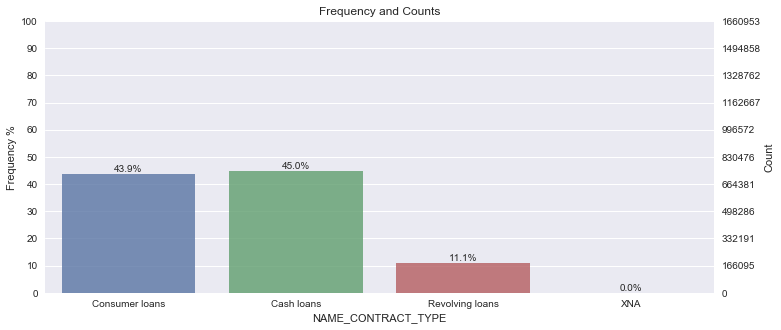

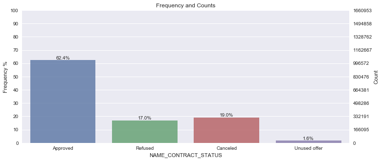

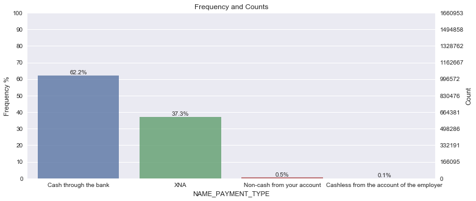

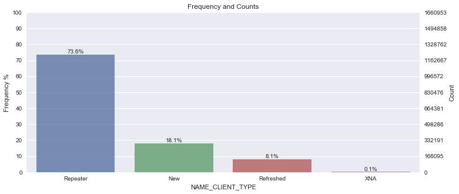

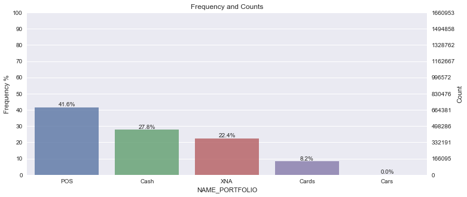

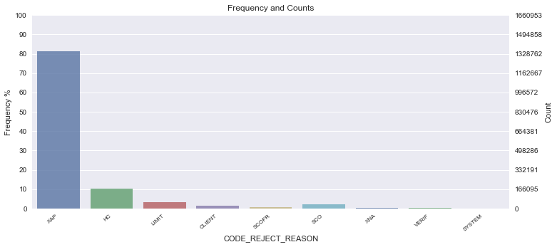

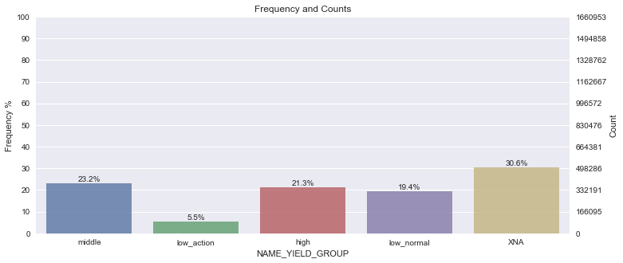

```python
# Plot counts for categorical features
previous_categorical_features  = ['NAME_CONTRACT_TYPE', 'NAME_CONTRACT_STATUS', 'NAME_PAYMENT_TYPE',
                                  'NAME_CLIENT_TYPE', 'NAME_PORTFOLIO', 'CODE_REJECT_REASON', 'NAME_YIELD_GROUP']

for f in previous_categorical_features:
    vs.plot_counts(previous_application_last, f)
```

```python
# Create dummy columns
previous_application_last, previous_application_dummy_cols_output = create_dummy(previous_application_last,
                                                                                 previous_categorical_features)

# Difference between amount of credit granted vs. applied
previous_application_last['AMT_CREDIT_APPLCATION_DIFF'] = \
previous_application_last['AMT_CREDIT'] - previous_application_last['AMT_APPLICATION']

# Display top n records
display(previous_application_last.head(n=1))
```

```
Dummy columns created!
```

|  | SK_ID_PREV | SK_ID_CURR | NAME_CONTRACT_TYPE | AMT_ANNUITY | AMT_APPLICATION | AMT_CREDIT | AMT_DOWN_PAYMENT | AMT_GOODS_PRICE | WEEKDAY_APPR_PROCESS_START | HOUR_APPR_PROCESS_START | ... | CODE_REJECT_REASON_SYSTEM | CODE_REJECT_REASON_VERIF | CODE_REJECT_REASON_XAP | CODE_REJECT_REASON_XNA | NAME_YIELD_GROUP_XNA | NAME_YIELD_GROUP_high | NAME_YIELD_GROUP_low_action | NAME_YIELD_GROUP_low_normal | NAME_YIELD_GROUP_middle | AMT_CREDIT_APPLCATION_DIFF |
| --- | --- | --- | --- | --- | --- | --- | --- | --- | --- | --- | --- | --- | --- | --- | --- | --- | --- | --- | --- | --- | --- |
| 0 | 2030495 | 271877 | Consumer loans | 1730.43 | 17145.0 | 17145.0 | 0.0 | 17145.0 | SATURDAY | 15 | ... | 0 | 0 | 1 | 0 | 0 | 0 | 0 | 0 | 1 | 0.0 |

1 rows × 73 columns

```python
# Columns to sum + key
previous_application_last_sum_cols = ['SK_ID_CURR', 'AMT_ANNUITY', 'AMT_APPLICATION', 'AMT_CREDIT',
                                       'AMT_DOWN_PAYMENT', 'AMT_GOODS_PRICE'] + previous_application_dummy_cols_output

# Get sums
previous_application_last_grouped = perform_aggregate(previous_application_last[previous_application_last_sum_cols],
                                                       ['SK_ID_CURR'], 'sum')

# Add _PREVIOUS suffix for final features since some columns overlap with other tables
previous_application_last_grouped = rename_cols_df(previous_application_last_grouped,
                                                    list(previous_application_last_grouped), 'previous')

# Display top n records
display(previous_application_last_grouped.head(n=1))
```

|  | SK_ID_CURR | AMT_ANNUITY_SUM_PREVIOUS | AMT_APPLICATION_SUM_PREVIOUS | AMT_CREDIT_SUM_PREVIOUS | AMT_DOWN_PAYMENT_SUM_PREVIOUS | AMT_GOODS_PRICE_SUM_PREVIOUS | NAME_CONTRACT_TYPE_CASH_LOANS_SUM_PREVIOUS | NAME_CONTRACT_TYPE_CONSUMER_LOANS_SUM_PREVIOUS | NAME_CONTRACT_TYPE_REVOLVING_LOANS_SUM_PREVIOUS | NAME_CONTRACT_TYPE_XNA_SUM_PREVIOUS | ... | CODE_REJECT_REASON_SCOFR_SUM_PREVIOUS | CODE_REJECT_REASON_SYSTEM_SUM_PREVIOUS | CODE_REJECT_REASON_VERIF_SUM_PREVIOUS | CODE_REJECT_REASON_XAP_SUM_PREVIOUS | CODE_REJECT_REASON_XNA_SUM_PREVIOUS | NAME_YIELD_GROUP_XNA_SUM_PREVIOUS | NAME_YIELD_GROUP_HIGH_SUM_PREVIOUS | NAME_YIELD_GROUP_LOW_ACTION_SUM_PREVIOUS | NAME_YIELD_GROUP_LOW_NORMAL_SUM_PREVIOUS | NAME_YIELD_GROUP_MIDDLE_SUM_PREVIOUS |
| --- | --- | --- | --- | --- | --- | --- | --- | --- | --- | --- | --- | --- | --- | --- | --- | --- | --- | --- | --- | --- | --- |
| 0 | 100001 | 3951.0 | 24835.5 | 23787.0 | 2520.0 | 24835.5 | 0 | 1 | 0 | 0 | ... | 0 | 0 | 0 | 1 | 0 | 0 | 1 | 0 | 0 | 0 |

1 rows × 41 columns

```python
# Columns to sum + key
previous_application_last_avg_cols = ['SK_ID_CURR', 'RATE_DOWN_PAYMENT', 'RATE_INTEREST_PRIMARY',
                                      'RATE_INTEREST_PRIVILEGED', 'CNT_PAYMENT', 'AMT_CREDIT_APPLCATION_DIFF']

# Get avgs
previous_application_last_avg_grouped = perform_aggregate(previous_application_last[previous_application_last_avg_cols],
                                                       ['SK_ID_CURR'], 'avg')

# Add _PREVIOUS suffix for final features since some columns overlap with other tables
previous_application_last_avg_grouped = rename_cols_df(previous_application_last_avg_grouped,
                                                    list(previous_application_last_avg_grouped), 'previous')

# Display top n records
display(previous_application_last_avg_grouped.head(n=1))
```

|  | SK_ID_CURR | RATE_DOWN_PAYMENT_AVG_PREVIOUS | RATE_INTEREST_PRIMARY_AVG_PREVIOUS | RATE_INTEREST_PRIVILEGED_AVG_PREVIOUS | CNT_PAYMENT_AVG_PREVIOUS | AMT_CREDIT_APPLCATION_DIFF_AVG_PREVIOUS |
| --- | --- | --- | --- | --- | --- | --- |
| 0 | 100001 | 0.104326 | 0.0 | 0.0 | 8.0 | -1048.5 |

```python
# Merge dict for previous_application_last_combined
previous_application_last_combined_merge_dict = {0: {'left': previous_application_last_grouped,
                                                    'right': previous_application_last_avg_grouped,
                                                    'how': 'inner',
                                                    'on': ['SK_ID_CURR']
                                                   }}

# Merge previous_application_last_grouped and previous_application_last_avg_grouped left join
previous_application_last_combined = merge_df(previous_application_last_combined_merge_dict)

# Display top n records
display(previous_application_last_combined.head(n=1))
```

|  | SK_ID_CURR | AMT_ANNUITY_SUM_PREVIOUS | AMT_APPLICATION_SUM_PREVIOUS | AMT_CREDIT_SUM_PREVIOUS | AMT_DOWN_PAYMENT_SUM_PREVIOUS | AMT_GOODS_PRICE_SUM_PREVIOUS | NAME_CONTRACT_TYPE_CASH_LOANS_SUM_PREVIOUS | NAME_CONTRACT_TYPE_CONSUMER_LOANS_SUM_PREVIOUS | NAME_CONTRACT_TYPE_REVOLVING_LOANS_SUM_PREVIOUS | NAME_CONTRACT_TYPE_XNA_SUM_PREVIOUS | ... | NAME_YIELD_GROUP_XNA_SUM_PREVIOUS | NAME_YIELD_GROUP_HIGH_SUM_PREVIOUS | NAME_YIELD_GROUP_LOW_ACTION_SUM_PREVIOUS | NAME_YIELD_GROUP_LOW_NORMAL_SUM_PREVIOUS | NAME_YIELD_GROUP_MIDDLE_SUM_PREVIOUS | RATE_DOWN_PAYMENT_AVG_PREVIOUS | RATE_INTEREST_PRIMARY_AVG_PREVIOUS | RATE_INTEREST_PRIVILEGED_AVG_PREVIOUS | CNT_PAYMENT_AVG_PREVIOUS | AMT_CREDIT_APPLCATION_DIFF_AVG_PREVIOUS |
| --- | --- | --- | --- | --- | --- | --- | --- | --- | --- | --- | --- | --- | --- | --- | --- | --- | --- | --- | --- | --- | --- |
| 0 | 100001 | 3951.0 | 24835.5 | 23787.0 | 2520.0 | 24835.5 | 0 | 1 | 0 | 0 | ... | 0 | 1 | 0 | 0 | 0 | 0.104326 | 0.0 | 0.0 | 8.0 | -1048.5 |

1 rows × 46 columns

```python
# previous_application_last_combined
# POS_CASH_balance_grouped
# credit_card_balance_grouped_final
# installments_payments_grouped

# Merge dict for previous_application_last_grouped_final
previous_application_last_grouped_final_merge_dict = {0: {'left': previous_application_last_combined,
                                                          'right': POS_CASH_balance_grouped,
                                                          'how': 'left',
                                                          'on': ['SK_ID_CURR']
                                                         },
                                                      1: {'left': None,
                                                          'right': credit_card_balance_grouped_final,
                                                          'how': 'left',
                                                          'on': ['SK_ID_CURR']
                                                         },
                                                      2: {'left': None,
                                                          'right': installments_payments_grouped,
                                                          'how': 'left',
                                                          'on': ['SK_ID_CURR']
                                                         }}

# Merge all
previous_application_last_grouped_final = merge_df(previous_application_last_grouped_final_merge_dict)

# Display top n records
display(previous_application_last_grouped_final.head(n=1))
```

|  | SK_ID_CURR | AMT_ANNUITY_SUM_PREVIOUS | AMT_APPLICATION_SUM_PREVIOUS | AMT_CREDIT_SUM_PREVIOUS | AMT_DOWN_PAYMENT_SUM_PREVIOUS | AMT_GOODS_PRICE_SUM_PREVIOUS | NAME_CONTRACT_TYPE_CASH_LOANS_SUM_PREVIOUS | NAME_CONTRACT_TYPE_CONSUMER_LOANS_SUM_PREVIOUS | NAME_CONTRACT_TYPE_REVOLVING_LOANS_SUM_PREVIOUS | NAME_CONTRACT_TYPE_XNA_SUM_PREVIOUS | ... | AMT_RECEIVABLE_PRINCIPAL_SUM_CREDIT_CARD_ACTIVE | AMT_RECIVABLE_SUM_CREDIT_CARD_ACTIVE | AMT_TOTAL_RECEIVABLE_SUM_CREDIT_CARD_ACTIVE | CNT_DRAWINGS_ATM_CURRENT_SUM_CREDIT_CARD_ACTIVE | CNT_DRAWINGS_CURRENT_SUM_CREDIT_CARD_ACTIVE | CNT_DRAWINGS_OTHER_CURRENT_SUM_CREDIT_CARD_ACTIVE | CNT_DRAWINGS_POS_CURRENT_SUM_CREDIT_CARD_ACTIVE | CNT_INSTALMENT_MATURE_CUM_SUM_CREDIT_CARD_ACTIVE | DAYS_INSTALMENT_PAYMENT_DIFF_AVG | AMT_INSTALMENT_PAYMENT_DIFF_AVG |
| --- | --- | --- | --- | --- | --- | --- | --- | --- | --- | --- | --- | --- | --- | --- | --- | --- | --- | --- | --- | --- | --- |
| 0 | 100001 | 3951.0 | 24835.5 | 23787.0 | 2520.0 | 24835.5 | 0 | 1 | 0 | 0 | ... | 0.0 | 0.0 | 0.0 | 0.0 | 0.0 | 0.0 | 0.0 | 0.0 | -7.285714 | 0.0 |

1 rows × 86 columns

```python
# application_combined
# previous_application_last_grouped_final
# bureau_combined_grouped_final

# Merge dict for previous_application_last_grouped_final
application_combined_final_merge_dict = {0: {'left': application_combined,
                                             'right': previous_application_last_grouped_final,
                                             'how': 'left',
                                             'on': ['SK_ID_CURR']
                                            },
                                         1: {'left': None,
                                             'right': bureau_combined_grouped_final,
                                             'how': 'left',
                                             'on': ['SK_ID_CURR']
                                            }}

# Merge all
application_combined_final = merge_df(application_combined_final_merge_dict)

# Scrub dummy columns.  This is run now to avoid updating original df.
application_combined_final = rename_cols_df(application_combined_final, application_dummy_cols_output, None)

# Display top n records
display(application_combined_final.head(n=1))
```

|  | AMT_ANNUITY | AMT_CREDIT | AMT_GOODS_PRICE | AMT_INCOME_TOTAL | AMT_REQ_CREDIT_BUREAU_DAY | AMT_REQ_CREDIT_BUREAU_HOUR | AMT_REQ_CREDIT_BUREAU_MON | AMT_REQ_CREDIT_BUREAU_QRT | AMT_REQ_CREDIT_BUREAU_WEEK | AMT_REQ_CREDIT_BUREAU_YEAR | ... | STATUS_C_SUM_HIST | STATUS_X_SUM_HIST | STATUS_0_SUM_LATEST | STATUS_1_SUM_LATEST | STATUS_2_SUM_LATEST | STATUS_3_SUM_LATEST | STATUS_4_SUM_LATEST | STATUS_5_SUM_LATEST | STATUS_C_SUM_LATEST | STATUS_X_SUM_LATEST |
| --- | --- | --- | --- | --- | --- | --- | --- | --- | --- | --- | --- | --- | --- | --- | --- | --- | --- | --- | --- | --- | --- |
| 0 | 24700.5 | 406597.5 | 351000.0 | 202500.0 | 0.0 | 0.0 | 0.0 | 0.0 | 0.0 | 1.0 | ... | 23.0 | 15.0 | 2.0 | 0.0 | 0.0 | 0.0 | 0.0 | 0.0 | 6.0 | 0.0 |

1 rows × 221 columns

```python
# Verify counts in final
print("Application combined records: {}".format(len(application_combined)))
print("Application combined final records: {}".format(len(application_combined_final)))
```

```
Application combined records: 356255
Application combined final records: 356255
```

## 3. Exploratory Visualization

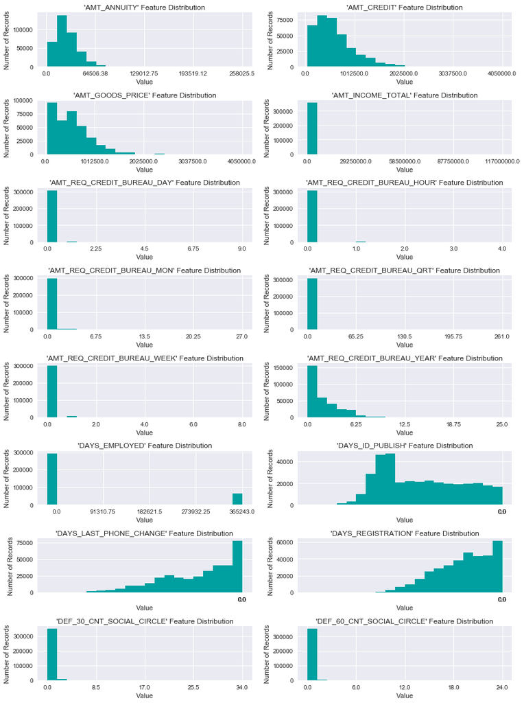

```python
# Plot histograms to review for any skewed features
skewed_review =  ['AMT_ANNUITY', 'AMT_CREDIT', 'AMT_GOODS_PRICE', 'AMT_INCOME_TOTAL',
                  'AMT_REQ_CREDIT_BUREAU_DAY', 'AMT_REQ_CREDIT_BUREAU_HOUR',
                  'AMT_REQ_CREDIT_BUREAU_MON', 'AMT_REQ_CREDIT_BUREAU_QRT',
                  'AMT_REQ_CREDIT_BUREAU_WEEK', 'AMT_REQ_CREDIT_BUREAU_YEAR',
                  'DAYS_EMPLOYED','DAYS_ID_PUBLISH', 'DAYS_LAST_PHONE_CHANGE', 'DAYS_REGISTRATION',
                  'DEF_30_CNT_SOCIAL_CIRCLE', 'DEF_60_CNT_SOCIAL_CIRCLE']

# Plot on application_combined_final
vs.plot_histograms(application_combined_final, skewed_review);
```

```python
# Numeric statistics for combined dataset
application_combined_final[skewed_review].describe()
```

|  | AMT_ANNUITY | AMT_CREDIT | AMT_GOODS_PRICE | AMT_INCOME_TOTAL | AMT_REQ_CREDIT_BUREAU_DAY | AMT_REQ_CREDIT_BUREAU_HOUR | AMT_REQ_CREDIT_BUREAU_MON | AMT_REQ_CREDIT_BUREAU_QRT | AMT_REQ_CREDIT_BUREAU_WEEK | AMT_REQ_CREDIT_BUREAU_YEAR | DAYS_EMPLOYED | DAYS_ID_PUBLISH | DAYS_LAST_PHONE_CHANGE | DAYS_REGISTRATION | DEF_30_CNT_SOCIAL_CIRCLE | DEF_60_CNT_SOCIAL_CIRCLE |
| --- | --- | --- | --- | --- | --- | --- | --- | --- | --- | --- | --- | --- | --- | --- | --- | --- |
| count | 356219.000000 | 3.562550e+05 | 3.559770e+05 | 3.562550e+05 | 308687.000000 | 308687.000000 | 308687.000000 | 308687.000000 | 308687.000000 | 308687.000000 | 356255.000000 | 356255.000000 | 356254.000000 | 356255.000000 | 355205.000000 | 355205.000000 |
| mean | 27425.560657 | 5.877674e+05 | 5.280200e+05 | 1.701161e+05 | 0.006281 | 0.005808 | 0.231697 | 0.304399 | 0.029995 | 1.911564 | 64317.231413 | -3002.071163 | -978.580852 | -4983.593527 | 0.143452 | 0.100198 |
| std | 14732.808190 | 3.986237e+05 | 3.660650e+05 | 2.235068e+05 | 0.104250 | 0.079736 | 0.855949 | 0.786915 | 0.191374 | 1.865338 | 141705.532576 | 1517.901735 | 835.063902 | 3526.968986 | 0.456579 | 0.368259 |
| min | 1615.500000 | 4.500000e+04 | 4.050000e+04 | 2.565000e+04 | 0.000000 | 0.000000 | 0.000000 | 0.000000 | 0.000000 | 0.000000 | -17912.000000 | -7197.000000 | -4361.000000 | -24672.000000 | 0.000000 | 0.000000 |
| 25% | 16731.000000 | 2.700000e+05 | 2.340000e+05 | 1.125000e+05 | 0.000000 | 0.000000 | 0.000000 | 0.000000 | 0.000000 | 0.000000 | -2781.000000 | -4318.000000 | -1592.000000 | -7477.000000 | 0.000000 | 0.000000 |
| 50% | 25078.500000 | 5.002110e+05 | 4.500000e+05 | 1.530000e+05 | 0.000000 | 0.000000 | 0.000000 | 0.000000 | 0.000000 | 1.000000 | -1224.000000 | -3252.000000 | -771.000000 | -4502.000000 | 0.000000 | 0.000000 |
| 75% | 34960.500000 | 7.975575e+05 | 6.750000e+05 | 2.025000e+05 | 0.000000 | 0.000000 | 0.000000 | 0.000000 | 0.000000 | 3.000000 | -290.000000 | -1717.000000 | -286.000000 | -1995.000000 | 0.000000 | 0.000000 |
| max | 258025.500000 | 4.050000e+06 | 4.050000e+06 | 1.170000e+08 | 9.000000 | 4.000000 | 27.000000 | 261.000000 | 8.000000 | 25.000000 | 365243.000000 | 0.000000 | 0.000000 | 0.000000 | 34.000000 | 24.000000 |

## 4. Data Preprocessing

```python
# Create df for feature transformations
features_transformed = application_combined_final.copy()
```

```python
# Check if any columns have missing values
numeric_nan_fill = features_transformed.columns[features_transformed.isnull().any()].tolist()

# Remove TARGET variable the nans are the test dataset in the combined df
numeric_nan_fill.remove('TARGET')

# Exclude the EXT_SOURCE for median nan replacement these will be replaced with a model
numeric_nan_fill.remove('EXT_SOURCE_1')
numeric_nan_fill.remove('EXT_SOURCE_2')
numeric_nan_fill.remove('EXT_SOURCE_3')

numeric_nan_fill
```

```
['AMT_ANNUITY',
 'AMT_GOODS_PRICE',
 'AMT_REQ_CREDIT_BUREAU_DAY',
 'AMT_REQ_CREDIT_BUREAU_HOUR',
 'AMT_REQ_CREDIT_BUREAU_MON',
 'AMT_REQ_CREDIT_BUREAU_QRT',
 'AMT_REQ_CREDIT_BUREAU_WEEK',
 'AMT_REQ_CREDIT_BUREAU_YEAR',
 'DAYS_LAST_PHONE_CHANGE',
 'DEF_30_CNT_SOCIAL_CIRCLE',
 'DEF_60_CNT_SOCIAL_CIRCLE',
 'OBS_30_CNT_SOCIAL_CIRCLE',
 'OBS_60_CNT_SOCIAL_CIRCLE']
```

```python
# Replace nan with median values per feature
for f in numeric_nan_fill:
    features_transformed[f].fillna((features_transformed[f].median()), inplace=True)

# Display top n records
display(features_transformed.head(n=1))
```

|  | AMT_ANNUITY | AMT_CREDIT | AMT_GOODS_PRICE | AMT_INCOME_TOTAL | AMT_REQ_CREDIT_BUREAU_DAY | AMT_REQ_CREDIT_BUREAU_HOUR | AMT_REQ_CREDIT_BUREAU_MON | AMT_REQ_CREDIT_BUREAU_QRT | AMT_REQ_CREDIT_BUREAU_WEEK | AMT_REQ_CREDIT_BUREAU_YEAR | ... | STATUS_C_SUM_HIST | STATUS_X_SUM_HIST | STATUS_0_SUM_LATEST | STATUS_1_SUM_LATEST | STATUS_2_SUM_LATEST | STATUS_3_SUM_LATEST | STATUS_4_SUM_LATEST | STATUS_5_SUM_LATEST | STATUS_C_SUM_LATEST | STATUS_X_SUM_LATEST |
| --- | --- | --- | --- | --- | --- | --- | --- | --- | --- | --- | --- | --- | --- | --- | --- | --- | --- | --- | --- | --- | --- |
| 0 | 24700.5 | 406597.5 | 351000.0 | 202500.0 | 0.0 | 0.0 | 0.0 | 0.0 | 0.0 | 1.0 | ... | 23.0 | 15.0 | 2.0 | 0.0 | 0.0 | 0.0 | 0.0 | 0.0 | 6.0 | 0.0 |

1 rows × 221 columns

```python
# DAYS_ columns to update
days_abs = ['DAYS_EMPLOYED','DAYS_ID_PUBLISH', 'DAYS_LAST_PHONE_CHANGE', 'DAYS_REGISTRATION']

# Transform negative to absolute for days columns since time is relative to application
features_transformed[days_abs] = features_transformed[days_abs].apply(lambda x: np.absolute(x))

# Scrub for positive data anomaly for DAYS_EMPLOYED
features_transformed.loc[(features_transformed['DAYS_EMPLOYED'] >= 365243), 'DAYS_EMPLOYED'] = 0
```

```python
# Log-transform the skewed features
features_transformed[skewed_review] = features_transformed[skewed_review].apply(lambda x: np.log(x + 1))
```

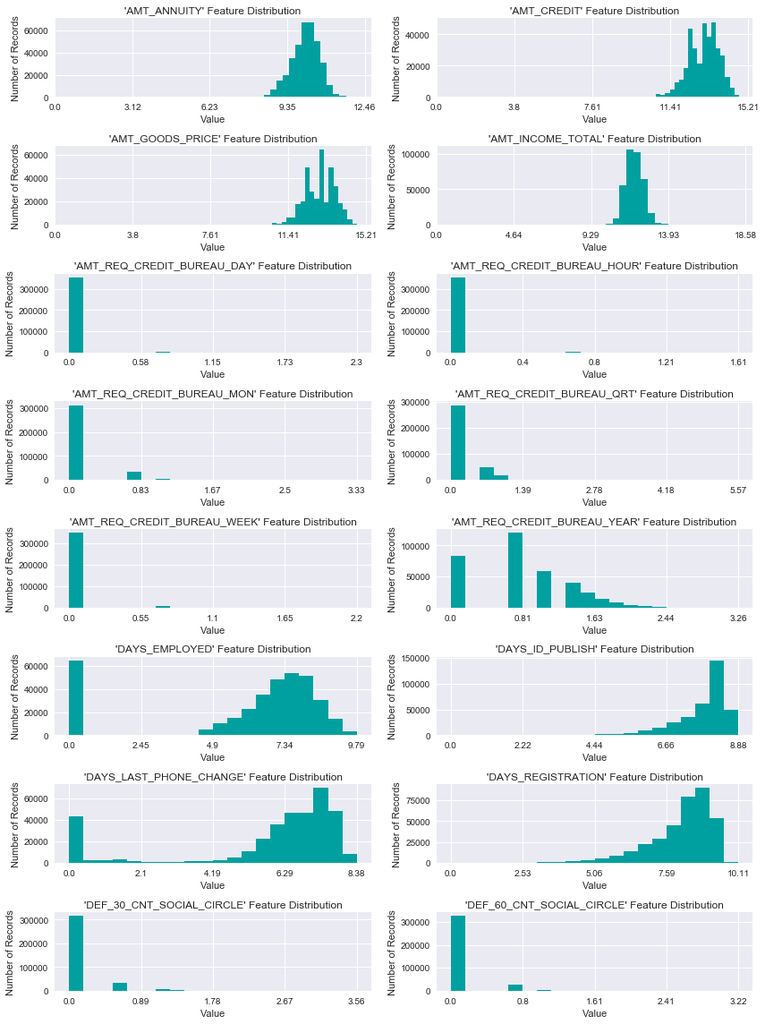

```python
vs.plot_histograms(features_transformed, skewed_review);
```

```python
# Predict and update missing values for EXT_SOURCE_
for c in ['EXT_SOURCE_1', 'EXT_SOURCE_2', 'EXT_SOURCE_3']:
    update_ext = predict_missing_ext(c)

    features_transformed = pd.merge(features_transformed, update_ext, on='SK_ID_CURR', how='left')

    features_transformed[c] = features_transformed[c].fillna(features_transformed[c + '_PRED'])

    drop_cols(features_transformed, [c + '_PRED'])
```

```python
# Review an example
application_combined_final[['SK_ID_CURR', 'EXT_SOURCE_1',
                            'EXT_SOURCE_2', 'EXT_SOURCE_3']][application_combined_final['SK_ID_CURR'] == 100006]

features_transformed[['SK_ID_CURR', 'EXT_SOURCE_1',
                      'EXT_SOURCE_2', 'EXT_SOURCE_3']][features_transformed['SK_ID_CURR'] == 100006]
```

[output not shown]

```python
# Create min, max, mean and median EXT_SOURCE after missing values updated
# MIN EXT_SOURCE
features_transformed['EXT_SOURCE_MIN'] = features_transformed[['EXT_SOURCE_1','EXT_SOURCE_2',
                                                               'EXT_SOURCE_3']].min(axis=1)

# MIN EXT_SOURCE
features_transformed['EXT_SOURCE_MAX'] = features_transformed[['EXT_SOURCE_1','EXT_SOURCE_2',
                                                               'EXT_SOURCE_3']].max(axis=1)

# MEAN EXT_SOURCE
features_transformed['EXT_SOURCE_AVG'] = features_transformed[['EXT_SOURCE_1','EXT_SOURCE_2',
                                                               'EXT_SOURCE_3']].mean(axis=1)

# MEDIAN EXT_SOURCE
features_transformed['EXT_SOURCE_MID'] = features_transformed[['EXT_SOURCE_1','EXT_SOURCE_2',
                                                               'EXT_SOURCE_3']].median(axis=1)

# Review header
features_transformed[['EXT_SOURCE_1','EXT_SOURCE_2', 'EXT_SOURCE_3',
                      'EXT_SOURCE_MIN', 'EXT_SOURCE_MAX',
                      'EXT_SOURCE_AVG', 'EXT_SOURCE_MID']].head(5)
```

|  | EXT_SOURCE_1 | EXT_SOURCE_2 | EXT_SOURCE_3 | EXT_SOURCE_MIN | EXT_SOURCE_MAX | EXT_SOURCE_AVG | EXT_SOURCE_MID |
| --- | --- | --- | --- | --- | --- | --- | --- |
| 0 | 0.083037 | 0.262949 | 0.139376 | 0.083037 | 0.262949 | 0.161787 | 0.139376 |
| 1 | 0.311267 | 0.622246 | 0.542313 | 0.311267 | 0.622246 | 0.491942 | 0.542313 |
| 2 | 0.415475 | 0.555912 | 0.729567 | 0.415475 | 0.729567 | 0.566985 | 0.555912 |
| 3 | 0.449913 | 0.650442 | 0.657622 | 0.449913 | 0.657622 | 0.585992 | 0.650442 |
| 4 | 0.463555 | 0.322738 | 0.650230 | 0.322738 | 0.650230 | 0.478841 | 0.463555 |

```python
# Import sklearn.preprocessing.StandardScaler
from sklearn.preprocessing import MinMaxScaler

# Initialize a scaler, then apply it to the features
scaler = MinMaxScaler() # default=(0, 1)
minmax_scale = [c for c in list(features_transformed) if c not in ['SK_ID_CURR','SOURCE','TARGET']]

features_transformed[minmax_scale] = scaler.fit_transform(features_transformed[minmax_scale])

# Display top n records
display(features_transformed.head(n = 1))
```

|  | AMT_ANNUITY | AMT_CREDIT | AMT_GOODS_PRICE | AMT_INCOME_TOTAL | AMT_REQ_CREDIT_BUREAU_DAY | AMT_REQ_CREDIT_BUREAU_HOUR | AMT_REQ_CREDIT_BUREAU_MON | AMT_REQ_CREDIT_BUREAU_QRT | AMT_REQ_CREDIT_BUREAU_WEEK | AMT_REQ_CREDIT_BUREAU_YEAR | ... | STATUS_2_SUM_LATEST | STATUS_3_SUM_LATEST | STATUS_4_SUM_LATEST | STATUS_5_SUM_LATEST | STATUS_C_SUM_LATEST | STATUS_X_SUM_LATEST | EXT_SOURCE_MIN | EXT_SOURCE_MAX | EXT_SOURCE_AVG | EXT_SOURCE_MID |
| --- | --- | --- | --- | --- | --- | --- | --- | --- | --- | --- | --- | --- | --- | --- | --- | --- | --- | --- | --- | --- | --- |
| 0 | 0.537494 | 0.489166 | 0.468924 | 0.245232 | 0.0 | 0.0 | 0.0 | 0.0 | 0.0 | 0.212746 | ... | 0.0 | 0.0 | 0.0 | 0.0 | 0.075 | 0.0 | 0.10292 | 0.247357 | 0.166422 | 0.156898 |

1 rows × 225 columns

```python
# Create training data from features_transformed
features_train = features_transformed[features_transformed['SOURCE'] == 'TRAIN'].copy()

features_train.shape
```

```
(307511, 225)
```

```python
# Create labels from train (need to convert back to int from combined)
labels_train = features_train['TARGET'].astype(int)

labels_train.shape
```

```
(307511,)
```

```python
# Create test data from combined
features_test = features_transformed[features_transformed['SOURCE'] == 'TEST'].copy()

features_test.shape
```

```
(48744, 225)
```

```python
# Create df to save SK_ID_CURR for submission file
id_test = features_test['SK_ID_CURR']

id_test.shape
```

```
(48744,)
```

```python
# Finally remove SOURCE, TARGET and SK_ID_CURR from features
drop_cols_final = ['SOURCE','TARGET', 'SK_ID_CURR']
drop_cols(features_train, drop_cols_final)
drop_cols(features_test, drop_cols_final)
```

## 5. Train and Evaluate Multiple Models

```python
# Import train_test_split
from sklearn.model_selection import train_test_split

# Split the features and target data into training and testing sets
X_train, X_test, y_train, y_test = train_test_split(features_train, labels_train, test_size=0.2, random_state=SEED)

# Show the results of the split
print("Training set has {} samples.".format(X_train.shape[0]))
print("Testing set has {} samples.".format(X_test.shape[0]))
```

```
Training set has 246008 samples.
Testing set has 61503 samples.
```

```python
# Import three supervised learning models
from sklearn.linear_model import LogisticRegression
from sklearn.ensemble import RandomForestClassifier
from xgboost.sklearn import XGBClassifier

# Initialize the three models
clf_A = LogisticRegression()
clf_B = RandomForestClassifier(random_state=SEED)
clf_C = XGBClassifier(objective='binary:logistic', random_state=SEED)

# Calculate the number of samples for 1%, 10%, and 100% of the training data
# samples_100 is the entire training set i.e. len(y_train)
# samples_10 is 10% of samples_100 (ensure to set the count of the values to be `int` and not `float`)
# samples_1 is 1% of samples_100 (ensure to set the count of the values to be `int` and not `float`)
samples_100 = len(y_train)
samples_10 = int(samples_100 * 0.1)
samples_1 = int(samples_100 * 0.01)

# Collect results on the learners
results = {}
for clf in [clf_A, clf_B, clf_C]:
    clf_name = clf.__class__.__name__
    results[clf_name] = {}
    for i, samples in enumerate([samples_1, samples_10, samples_100]):
        results[clf_name][i] = \
        train_predict(clf, samples, X_train, y_train, X_test, y_test)
```

```
LogisticRegression trained on 2460 samples.
LogisticRegression trained on 24600 samples.
LogisticRegression trained on 246008 samples.
RandomForestClassifier trained on 2460 samples.
RandomForestClassifier trained on 24600 samples.
RandomForestClassifier trained on 246008 samples.
XGBClassifier trained on 2460 samples.
XGBClassifier trained on 24600 samples.
XGBClassifier trained on 246008 samples.
```

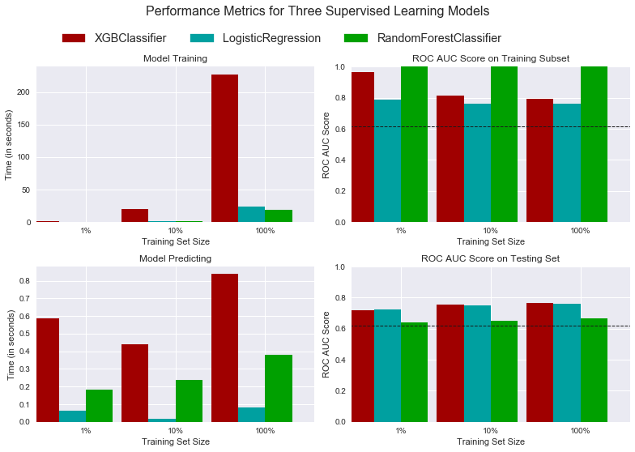

```python
# Evaluate results with benchmark roc_auc_score
vs.evaluate(results, roc_auc=.618)
```

```python
# Print results for XGBClassifier
print(results['XGBClassifier'])
```

[output not shown]

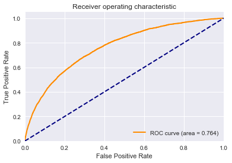

```python
# ROC AUC Curve for XGBoost default
y_scores = clf_C.predict_proba(X_test)

vs.plot_roc_auc_curve(y_test, y_scores[:, 1])
```

## 6. Implementation and Tune Final Model

```python
# Import xgboost library
import xgboost as xgb

# Create dmatrix for train
xgb_train = xgb.DMatrix(X_train, y_train)

# Create dmatrix for test
xgb_test = xgb.DMatrix(X_test, y_test)
```

**Perform some cross-validation analysis on tree parameters to identify smaller range of options for grid search.**

```python
# max_depth
param = 'max_depth'
values = [3, 5, 7]
input_params = {'objective': 'binary:logistic', 'random_state': SEED}
cv_result = cv_result_analysis(input_params, xgb_train, param, values,
                              num_boost_round=20, early_stopping_rounds=5, verbose_eval=10)
```

```
max_depth cv results for:
{'objective': 'binary:logistic', 'random_state': 42, 'max_depth': 3}
max_depth cv results for:
{'objective': 'binary:logistic', 'random_state': 42, 'max_depth': 5}
max_depth cv results for:
{'objective': 'binary:logistic', 'random_state': 42, 'max_depth': 7}
```

```python
# min_child_weight
param = 'min_child_weight'
values = [20, 40, 80]
input_params = {'max_depth': 7, # for min_child_weight increase depth for better view of impact
                'objective': 'binary:logistic', 'random_state': SEED}
cv_result = cv_result_analysis(input_params, xgb_train, param, values,
                              num_boost_round=20, early_stopping_rounds=5, verbose_eval=10)
```

```
min_child_weight cv results for:
{'objective': 'binary:logistic', 'random_state': 42, 'max_depth': 7, 'min_child_weight': 20}
min_child_weight cv results for:
{'objective': 'binary:logistic', 'random_state': 42, 'max_depth': 7, 'min_child_weight': 40}
min_child_weight cv results for:
{'objective': 'binary:logistic', 'random_state': 42, 'max_depth': 7, 'min_child_weight': 80}
```

```python
# gamma
param = 'gamma'
values = [5, 10, 20]
input_params = {'max_depth': 7, # increase depth for better view of impact
                'objective': 'binary:logistic', 'random_state': SEED}
cv_result = cv_result_analysis(input_params, xgb_train, param, values,
                              num_boost_round=20, early_stopping_rounds=5, verbose_eval=10)
```

```
gamma cv results for:
{'objective': 'binary:logistic', 'random_state': 42, 'max_depth': 7, 'gamma': 5}
gamma cv results for:
{'objective': 'binary:logistic', 'random_state': 42, 'max_depth': 7, 'gamma': 10}
gamma cv results for:
{'objective': 'binary:logistic', 'random_state': 42, 'max_depth': 7, 'gamma': 20}
```

```python
from sklearn.model_selection import GridSearchCV

# Base mode with fixed parameters
xgb_search = xgb.XGBClassifier(objective='binary:logistic',
                               n_estimators=20, # 20 rounds only for grid search
                               learning_rate=.15, # increase learning rate for grid search since only 20 rounds
                               scale_pos_weight=.9, # Set to .9 due to imbalanced target
                               random_state=SEED)

# Search parameters
search_params = {'max_depth': [5, 7],
                 'min_child_weight': [40, 80],
                 'gamma': [10, 20]
                }

# Search for optimal paramaters
search_clf = GridSearchCV(xgb_search, param_grid=search_params, scoring='roc_auc', cv=5)

# Fit grid search classifier
search_clf.fit(X_train, y_train)

# Get the best estimator
search_clf.best_estimator_
```

```
XGBClassifier(base_score=0.5, booster='gbtree', colsample_bylevel=1,
       colsample_bytree=1, gamma=10, learning_rate=0.15, max_delta_step=0,
       max_depth=7, min_child_weight=40, missing=None, n_estimators=20,
       n_jobs=1, nthread=None, objective='binary:logistic',
       random_state=42, reg_alpha=0, reg_lambda=1, scale_pos_weight=0.9,
       seed=None, silent=True, subsample=1)
```

```python
# Model params
input_params = {'max_depth': 7, 'min_child_weight': 40, 'gamma': 10,
                'colsample_bytree': 1, 'subsample': .75,
                'reg_alpha': 5, 'reg_lambda': 1,
                'learning_rate': .1,
                'scale_pos_weight': .9,
                'objective': 'binary:logistic', 'eval_metric': 'auc',
                'random_state': SEED}
watchlist= [(xgb_test, 'test')]

# Train classifier
xgb_clf = xgb.train(params=input_params, dtrain=xgb_train,
                        num_boost_round=500, early_stopping_rounds=50,
                        evals=watchlist, verbose_eval=50)
```

[output not shown]

## 7. Evaluation and Make Predictions

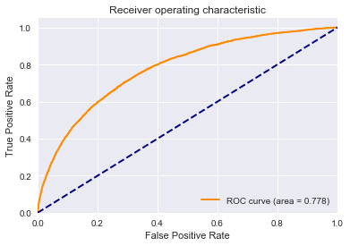

```python
# Get prediction proba (xgb default output is proba)
y_scores_final = xgb_clf.predict(xgb.DMatrix(X_test))

vs.plot_roc_auc_curve(y_test, y_scores_final)
```

```python
from sklearn.metrics import roc_auc_score

y_scores_train = xgb_clf.predict(xgb.DMatrix(X_train))

print("AUC score on training data: {:.3f}".format(roc_auc_score(y_train, y_scores_train)))
print("AUC score on testing data: {:.3f}".format(roc_auc_score(y_test, y_scores_final)))
```

```
AUC score on training data: 0.815
AUC score on testing data: 0.778
```

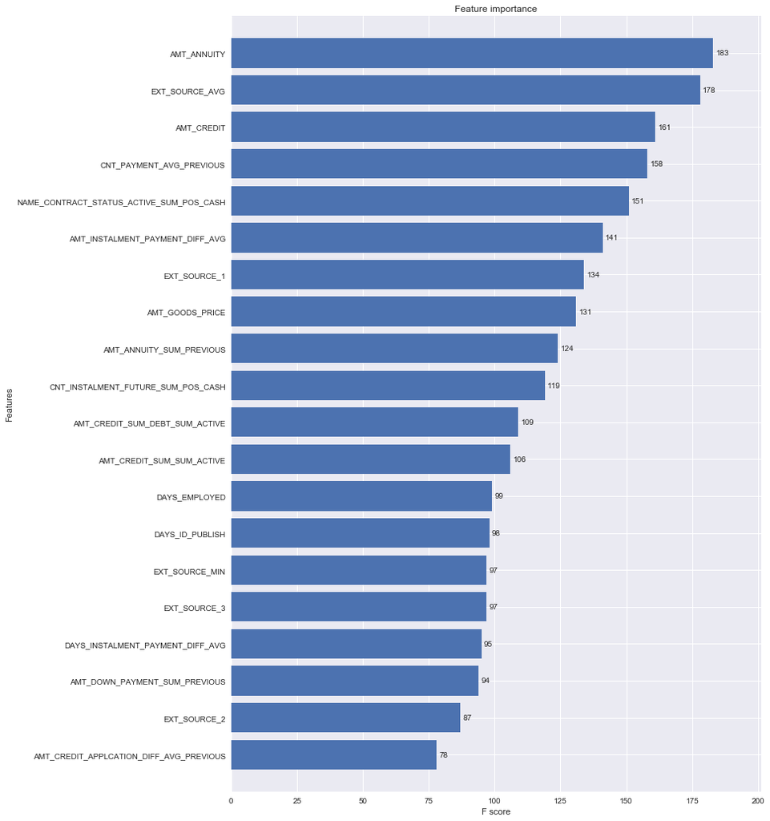

```python
# Plot feature importance
fig, ax = plt.subplots(figsize=(12,18))
xgb.plot_importance(xgb_clf, max_num_features=20, height=0.8, ax=ax);
```

```python
# Make Predictions and Create Submission csv
y_scores_submission = xgb_clf.predict(xgb.DMatrix(features_test))

submission = create_submission(id_test, y_scores_submission)

create_output(submission, 'xgb_tuned_v2.csv')
```